# Cardiovascular Disease Data Analysis and Prediction

Giovanni Billo, Muhammad Mubashar Shahzad, Carlos Velázquez Fernández, Fabio Vicig

2025-01-07

## Introduction

The analysis is centered around the prediction of presence of cardiovascular disease, given data about patients (Ulianova n.d.). The data includes different categorical and numerical variables commonly associated to an individual’s health status. After a brief data exploration, we perform first cluster analysis on the dataset and then fit different types of models (Trees and Random Forest, Logistic regression models and natural splines). All of these deliver a similar performance, but some are more explainable than others. Finally, we discuss some issues with the data, considering its unknown origin and unspecified gathering methods, and hint at how this work could possibly be improved.

## Importing libraries

```r
packages <- c("arm", "caret", "cluster", "corrplot", "dendextend", "doParallel", "dplyr",
              "effects", "GGally", "ggplot2", "glmnet", "gridExtra", "MASS", "patchwork", "parallel",
              "pROC", "ranger", "reshape2", "rpart", "rpart.plot", "splines")

install_if_missing <- function(pkg) {
  if (!require(pkg, character.only = TRUE, quietly = TRUE)) {
    install.packages(pkg, dependencies = TRUE)
  }
}

suppressMessages(invisible(lapply(packages, install_if_missing)))
```

```r
suppressMessages(library(arm))
suppressMessages(library(caret))
suppressMessages(library(cluster))
suppressMessages(library(corrplot))
suppressMessages(library(dendextend))
suppressMessages(library(doParallel))
suppressMessages(library(dplyr))
suppressMessages(library(effects))
suppressMessages(library(GGally))
suppressMessages(library(ggplot2))
suppressMessages(library(glmnet))
suppressMessages(library(gridExtra))
suppressMessages(library(MASS))
suppressMessages(library(parallel))
suppressMessages(library(patchwork))
suppressMessages(library(pROC))
suppressMessages(library(ranger))
suppressMessages(library(reshape2))
suppressMessages(library(rpart))
suppressMessages(library(rpart.plot))
suppressMessages(library(splines))
```

## Data exploration

Firstly, an exploratory analysis has been conducted, with the purpose of identifying problems and have at a glance an idea of meaning and distribution of the variables.

The dataset contains 70000 observations of 12 variables. The source doesn’t specify how the data was recovered or generated, and it has not been possible to find it elsewhere than Kaggle. The variables are the following:

- **cardio** : objective variable of our analysis. It is a binary variable representing whether cardiovascular disease is present in the patient.
- **age** : age of the patient, in days.
- **gender** : categorical variable which is 1 for females and 2 for males.
- **height** : height of the patient, in cm.
- **weight** : weight of the patient, in kg.
- **ap_hi** : systolic blood pressure.
- **ap_lo** : diastolic blood pressure.
- **cholesterol** : categorical variable with three levels of cholesterol: 1: normal, 2: above normal, 3: well above normal.
- **gluc** : categorical variable with three levels of glucose: 1: normal, 2: above normal, 3: well above normal.
- **smoke** : binary variable, representing smokers.
- **alco** : binary variable, representing alcohol intake.
- **active** : binary variable, representing physical activity.

The last three variables are marked as “subjective”, meaning that this piece of information is likely supplied by patients themselves, possibly using different metrics.

### Preprocessing

First of all, we need to check if there are NA values in the data:

```r
cardio_with_id <- read.csv("data/cardio_train.csv", sep= ";", header=TRUE)
cardio <- cardio_with_id[,-1]
str(cardio)
```

```
## 'data.frame':    70000 obs. of  12 variables:
##  $ age        : int  18393 20228 18857 17623 17474 21914 22113 22584 17668 19834 ...
##  $ gender     : int  2 1 1 2 1 1 1 2 1 1 ...
##  $ height     : int  168 156 165 169 156 151 157 178 158 164 ...
##  $ weight     : num  62 85 64 82 56 67 93 95 71 68 ...
##  $ ap_hi      : int  110 140 130 150 100 120 130 130 110 110 ...
##  $ ap_lo      : int  80 90 70 100 60 80 80 90 70 60 ...
##  $ cholesterol: int  1 3 3 1 1 2 3 3 1 1 ...
##  $ gluc       : int  1 1 1 1 1 2 1 3 1 1 ...
##  $ smoke      : int  0 0 0 0 0 0 0 0 0 0 ...
##  $ alco       : int  0 0 0 0 0 0 0 0 0 0 ...
##  $ active     : int  1 1 0 1 0 0 1 1 1 0 ...
##  $ cardio     : int  0 1 1 1 0 0 0 1 0 0 ...
```

```r
sum(as.numeric(is.na(cardio)))
```

```
## [1] 0
```

It seems like there are no NA values. Let’s check some other general metrics:

```r
summary(cardio)
```

```
##       age            gender         height          weight
##  Min.   :10798   Min.   :1.00   Min.   : 55.0   Min.   : 10.00
##  1st Qu.:17664   1st Qu.:1.00   1st Qu.:159.0   1st Qu.: 65.00
##  Median :19703   Median :1.00   Median :165.0   Median : 72.00
##  Mean   :19469   Mean   :1.35   Mean   :164.4   Mean   : 74.21
##  3rd Qu.:21327   3rd Qu.:2.00   3rd Qu.:170.0   3rd Qu.: 82.00
##  Max.   :23713   Max.   :2.00   Max.   :250.0   Max.   :200.00
##      ap_hi             ap_lo           cholesterol         gluc
##  Min.   : -150.0   Min.   :  -70.00   Min.   :1.000   Min.   :1.000
##  1st Qu.:  120.0   1st Qu.:   80.00   1st Qu.:1.000   1st Qu.:1.000
##  Median :  120.0   Median :   80.00   Median :1.000   Median :1.000
##  Mean   :  128.8   Mean   :   96.63   Mean   :1.367   Mean   :1.226
##  3rd Qu.:  140.0   3rd Qu.:   90.00   3rd Qu.:2.000   3rd Qu.:1.000
##  Max.   :16020.0   Max.   :11000.00   Max.   :3.000   Max.   :3.000
##      smoke              alco             active           cardio
##  Min.   :0.00000   Min.   :0.00000   Min.   :0.0000   Min.   :0.0000
##  1st Qu.:0.00000   1st Qu.:0.00000   1st Qu.:1.0000   1st Qu.:0.0000
##  Median :0.00000   Median :0.00000   Median :1.0000   Median :0.0000
##  Mean   :0.08813   Mean   :0.05377   Mean   :0.8037   Mean   :0.4997
##  3rd Qu.:0.00000   3rd Qu.:0.00000   3rd Qu.:1.0000   3rd Qu.:1.0000
##  Max.   :1.00000   Max.   :1.00000   Max.   :1.0000   Max.   :1.0000
```

From the summary we can see that there are variables with impossible values: specifically, `ap_hi` and `ap_lo` have in some cases negative values, which doesn’t make sense (even for a dead person), and in other cases extremely high values.

A cut-off value value for the blood pressure is selected (generously) by basing on a study that measured blood pressure during intense exercise, and found a maximum pressure of 370/360 while using the Valsalva and a maximum of 250/230 without it (Narloch and Brandstater 1995).

```r
summary(cardio[(cardio$ap_hi<0|cardio$ap_hi>400|cardio$ap_lo<0|cardio$ap_lo>400|cardio$ap_hi<cardio$ap_lo),])
```

```
##       age            gender        height          weight
##  Min.   :14297   Min.   :1.0   Min.   : 66.0   Min.   : 10.00
##  1st Qu.:18182   1st Qu.:1.0   1st Qu.:158.0   1st Qu.: 68.00
##  Median :19862   Median :1.0   Median :165.0   Median : 77.00
##  Mean   :19716   Mean   :1.4   Mean   :164.3   Mean   : 78.98
##  3rd Qu.:21635   3rd Qu.:2.0   3rd Qu.:170.0   3rd Qu.: 89.00
##  Max.   :23652   Max.   :2.0   Max.   :200.0   Max.   :181.00
##      ap_hi             ap_lo          cholesterol         gluc
##  Min.   : -150.0   Min.   :  -70.0   Min.   :1.000   Min.   :1.000
##  1st Qu.:  130.0   1st Qu.:  182.5   1st Qu.:1.000   1st Qu.:1.000
##  Median :  150.0   Median : 1000.0   Median :1.000   Median :1.000
##  Mean   :  244.7   Mean   :  926.0   Mean   :1.487   Mean   :1.272
##  3rd Qu.:  160.0   3rd Qu.: 1000.0   3rd Qu.:2.000   3rd Qu.:1.000
##  Max.   :16020.0   Max.   :11000.0   Max.   :3.000   Max.   :3.000
##      smoke             alco             active           cardio
##  Min.   :0.0000   Min.   :0.00000   Min.   :0.0000   Min.   :0.0000
##  1st Qu.:0.0000   1st Qu.:0.00000   1st Qu.:1.0000   1st Qu.:1.0000
##  Median :0.0000   Median :0.00000   Median :1.0000   Median :1.0000
##  Mean   :0.0989   Mean   :0.07692   Mean   :0.8218   Mean   :0.7708
##  3rd Qu.:0.0000   3rd Qu.:0.00000   3rd Qu.:1.0000   3rd Qu.:1.0000
##  Max.   :1.0000   Max.   :1.00000   Max.   :1.0000   Max.   :1.0000
```

```r
cardio <- cardio[!(cardio$ap_hi < 25 | cardio$ap_hi > 400 | cardio$ap_lo <  10| cardio$ap_lo > 400 | cardio$ap_hi < (cardio$ap_lo + 1) | cardio$ap_hi-cardio$ap_lo > 160),]
```

1274 observations have completely unrealistic values for either systolic or diastolic pressure (or both). In 274 of them, the systolic pressure is less than the diastolic, which is also not possible. These wrong metrics are less than 2% of the dataset, so the most straightforward approach is just to eliminate the problematic rows.

In order to make data more understandable, we will transform the age (currently in days) to years.

```r
cardio$age = cardio$age/365
summary(cardio$age)
```

```
##    Min. 1st Qu.  Median    Mean 3rd Qu.    Max.
##   29.58   48.38   53.98   53.33   58.42   64.97
```

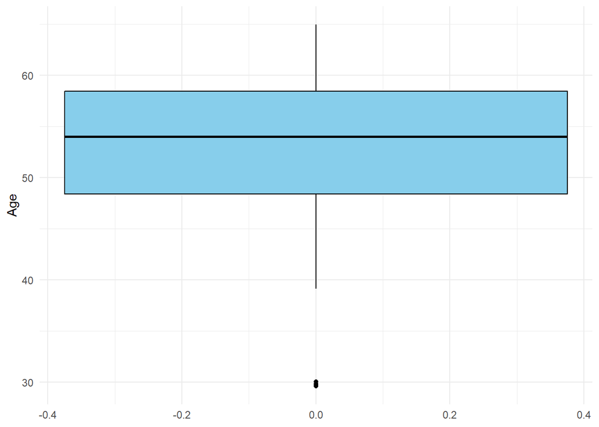

```r
ggplot(cardio, aes(y = age)) +
  geom_boxplot(fill = "skyblue", color = "black") + labs(
    y = "Age"
  ) +
  theme_minimal()
```

```r
nrow(cardio[cardio$age<39,])
```

```
## [1] 4
```

Given that there are only 4 observations concerning people < 39 years old, and the youngest one in the sample is 29, we will split data between under (or equal to) and over 55.

```r
cardio$age_cat <- ifelse(cardio$age <= 55, '30-55', '55-65')
table(cardio$age_cat)
```

```
##
## 30-55 55-65
## 38077 30622
```

Factorization must also be applied to some variables:

```r
# saving a copy of cardio without factor columns later on
cardio_cl <- subset(cardio, select = -age_cat)

cardio$gender <- factor(cardio$gender)
levels(cardio$gender) = c("F", "M")

cardio$cardio <- as.factor(cardio$cardio)

cardio$cholesterol <- factor(cardio$cholesterol)
levels(cardio$cholesterol) = c("normal", "above normal", "well above normal")

cardio$gluc <- factor(cardio$gluc)
levels(cardio$gluc) = c("normal", "above normal", "well above normal")

cardio$smoke <- factor(cardio$smoke)
levels(cardio$smoke) = c("No", "Yes")

cardio$alco <- factor(cardio$alco)
levels(cardio$alco) = c("No", "Yes")

cardio$active <- factor(cardio$active)
levels(cardio$active) = c("No", "Yes")

cardio$age_cat <- factor(cardio$age_cat)
levels(cardio$age_cat) = c("Under 55", "Over 55")
```

### Distribution

It is important to know the proportion of classes in the target variable.

```r
table(cardio$cardio)
```

```
##
##     0     1
## 34711 33988
```

It looks like the dataset is balanced with respect to `cardio`.

For convenience, numerical and categorical variables will be specified:

```r
numerical <- cardio[, c("age", "height", "weight", "ap_hi", "ap_lo")]
categorical <- cardio[!(names(cardio) %in% c("age", "height", "weight", "ap_hi", "ap_lo"))]
```

Let’s explore first the frequency of the **numerical** variables in a more visual way:

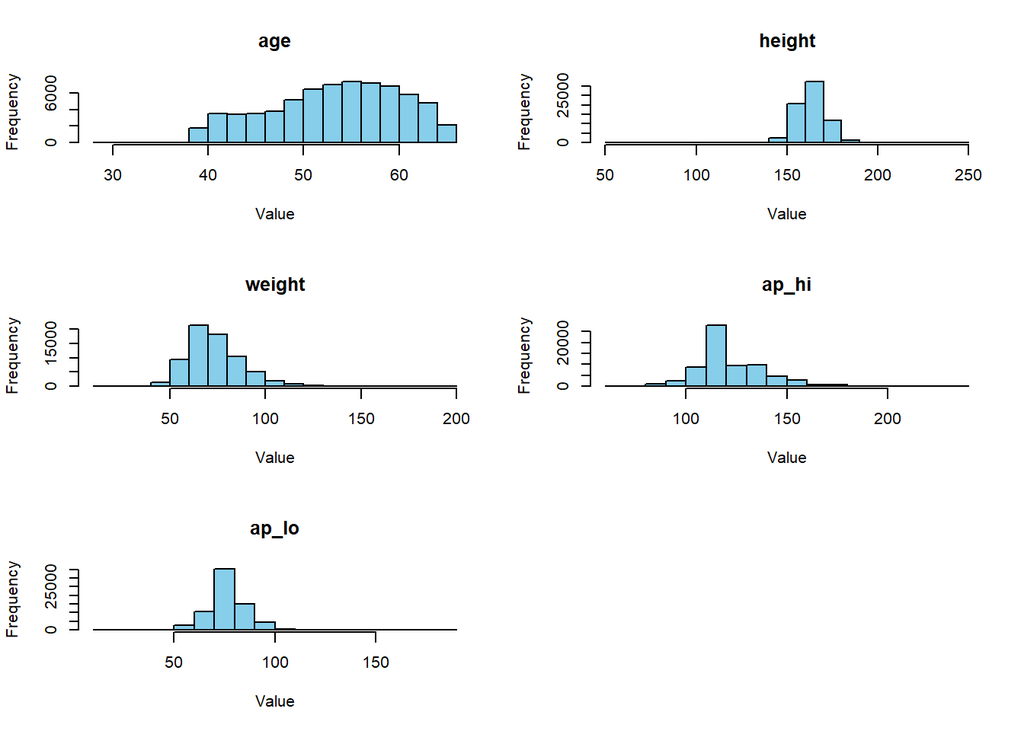

```r
num_vars <- ncol(numerical)
par(mfrow = c(ceiling(sqrt(num_vars)), floor(sqrt(num_vars))))
for (i in 1:num_vars) {
    hist(
        numerical[[i]], col = "skyblue",main=colnames(numerical)[i], xlab = "Value", ylab = "Frequency", border = "black"   )
}
```

We now proceed to plot the distribution of the numerical variables, also with respect to the disease status:

```r
set.seed(123)
custom_colors <- c("royalblue", "lightcoral")

plot.new()
pairs(
  numerical,
  labels = colnames(numerical),
  pch = 'o',
  bg = custom_colors[as.numeric(as.character(cardio$cardio)) + 1],
  col = custom_colors[as.numeric(as.character(cardio$cardio)) + 1],
  main = "\n",
  row1attop = TRUE,
  gap = 1,
  cex.labels = 1,
  cex = 0.8
)
legend(
  "topleft",
  legend = c("No disease", "Disease"),
  col = custom_colors,
  pch = 'o',
  pt.bg = custom_colors,
  bty = "n",
  xpd = TRUE,  # Allow drawing outside the plot area
  inset = c(0.8, -0.17)
)
```

[output not shown]

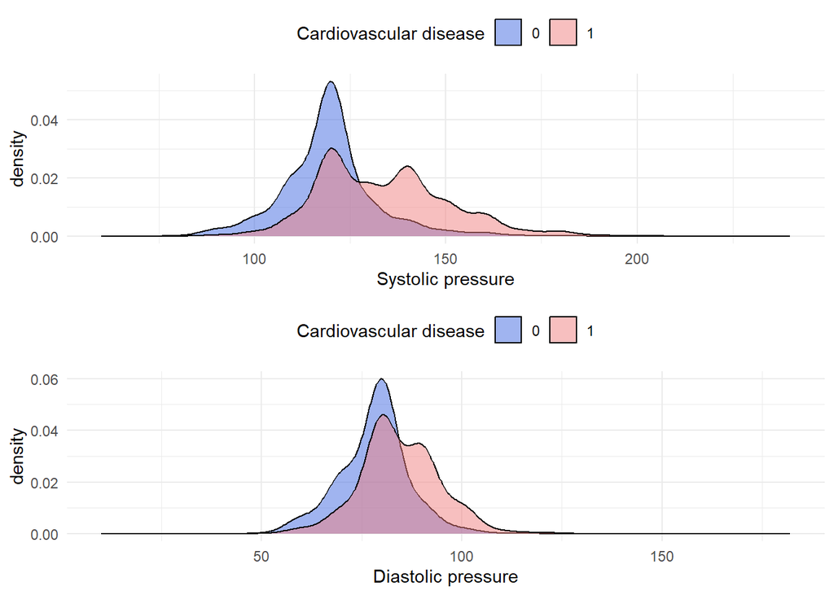

```r
gdens1<- ggplot(cardio, aes(x = ap_hi, fill = factor(cardio))) +
  geom_density(alpha = 0.5,bw = 4) +
  scale_fill_manual(values = c("0" = "royalblue", "1" = "lightcoral")) +
  labs(fill = "Cardiovascular disease", x = "Systolic pressure") +
  theme_minimal() +
  theme(legend.position = "top")
gdens2<-ggplot(cardio, aes(x = ap_lo, fill = factor(cardio))) +
  geom_density(alpha = 0.5,bw = 4) +
  scale_fill_manual(values = c("0" = "royalblue", "1" = "lightcoral")) +
  labs(fill = "Cardiovascular disease", x = "Diastolic pressure") +
  theme_minimal() +
  theme(legend.position = "top")
gdens3<-ggplot(cardio, aes(x = ap_hi-ap_lo, fill = factor(cardio))) +
  geom_density(alpha = 0.5,bw = 4) +
  scale_fill_manual(values = c("0" = "royalblue", "1" = "lightcoral")) +
  labs(fill = "Cardiovascular disease", x = "Pulse pressure") +
  theme_minimal() +
  theme(legend.position = "top")
gdens4<-ggplot(cardio, aes(x = height, fill = factor(cardio))) +
  geom_density(alpha = 0.5,bw = 2) +
  scale_fill_manual(values = c("0" = "royalblue", "1" = "lightcoral")) +
  labs(fill = "Cardiovascular disease", x = "Height") +
  theme_minimal() +
  theme(legend.position = "top")
gdens5<-ggplot(cardio, aes(x = weight, fill = factor(cardio))) +
  geom_density(alpha = 0.5,bw = 2) +
  scale_fill_manual(values = c("0" = "royalblue", "1" = "lightcoral")) +
  labs(fill = "Cardiovascular disease", x = "Weight") +
  theme_minimal() +
  theme(legend.position = "top")
gdens6<-ggplot(cardio, aes(x = age, fill = factor(cardio))) +
  geom_density(alpha = 0.5,bw = 1) +
  scale_fill_manual(values = c("0" = "royalblue", "1" = "lightcoral")) +
  labs(fill = "Cardiovascular disease", x = "Age") +
  theme_minimal() +
  theme(legend.position = "top")
grid.arrange(gdens1,gdens2, nrow = 2)
```

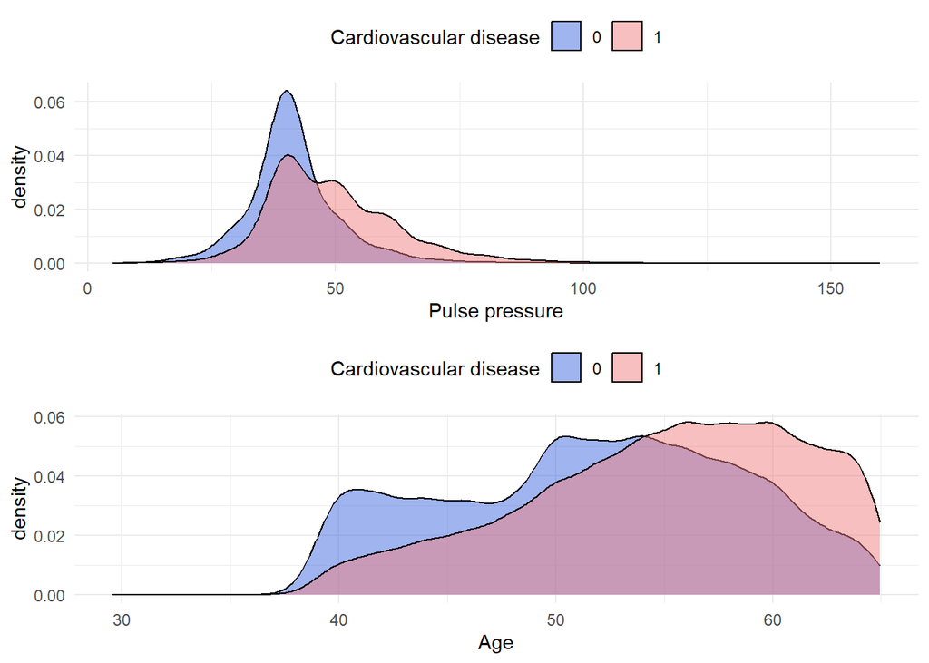

```r
grid.arrange(gdens3,gdens6, nrow = 2)
```

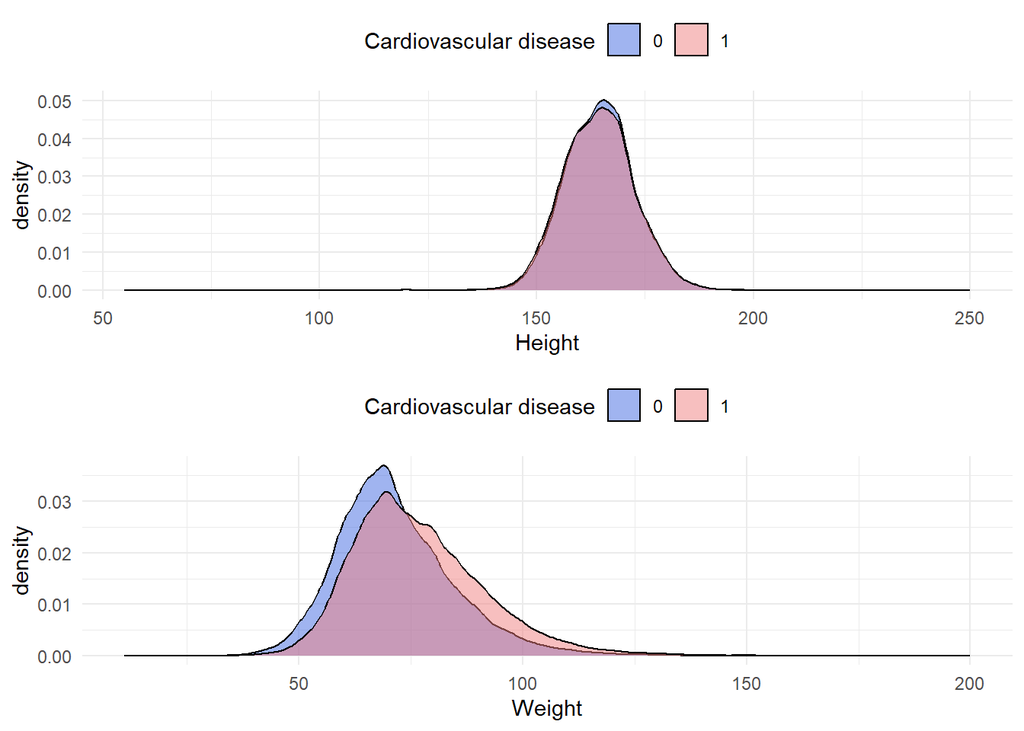

```r
grid.arrange(gdens4,gdens5, nrow = 2)
```

```r
if (!dir.exists("images")) {
  dir.create("images")
}

save_plots <- function(plot_list){
  # Save each plot to the "images" directory using png() device
  for (plot_name in names(plot_list)) {
    # Open a PNG device
    png(filename = paste0("images/", plot_name, ".png"), width = 800, height = 600, res = 300)

    # Print the plot
    print(plot_list[[plot_name]])

    # Close the device
    dev.off()
  }
}
plots_density <- list(
  gdens1 = gdens1,
  gdens2 = gdens2,
  gdens3 = gdens3,
  gdens4 = gdens4,
  gdens5 = gdens5,
  gdens6 = gdens6
)
save_plots(plots_density)
```

Now let’s explore the possible relationships of the **categorical** variables with respect to `cardio`.

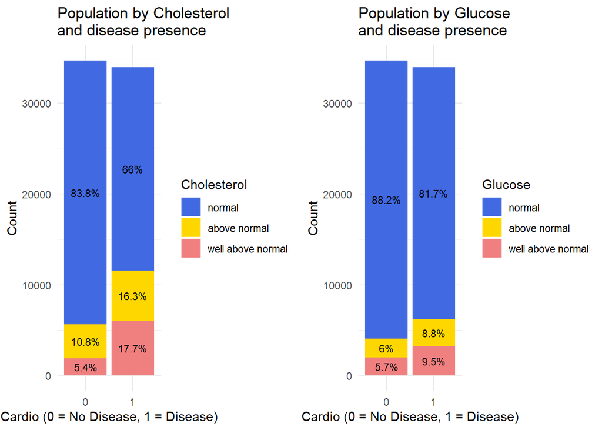

```r
stacked_bplot <- function(data, x, fill, fill_colors, title, x_label, y_label, fill_label) {
  data <- aggregate(x = list(count = rep(1, nrow(data))), by = list(cardio = data$cardio, group = data[[fill]]), FUN = sum)
  data$total <- ave(data$count, data$cardio, FUN = sum)
  data$percentage <- (data$count / data$total) * 100
  ggplot(data, aes(x = as.factor(cardio), y = count, fill = as.factor(group))) +
    geom_bar(stat = "identity", position = "stack") +
    geom_text(aes(label = paste0(round(percentage, 1), "%")), position = position_stack(vjust = 0.5), size = 3) +
    labs(title = title, x = x_label, y = y_label, fill = fill_label) +
    scale_fill_manual(values = fill_colors) +
    theme_minimal()
}

pChol <- stacked_bplot(cardio, "cardio", "cholesterol", c("royalblue", "gold", "lightcoral"),
  "Population by Cholesterol \nand disease presence", "Cardio (0 = No Disease, 1 = Disease)", "Count", "Cholesterol"
)

pGluc <- stacked_bplot(cardio, "cardio", "gluc", c("royalblue", "gold", "lightcoral"),
  "Population by Glucose \nand disease presence", "Cardio (0 = No Disease, 1 = Disease)", "Count", "Glucose"
)

pSmoke <- stacked_bplot(cardio, "cardio", "smoke", c("royalblue", "lightcoral"),
  "Population by Smoking Status \nand disease presence", "Cardio (0 = No Disease, 1 = Disease)", "Count", "Smoking"
)

pActive <- stacked_bplot(cardio, "cardio", "active", c("lightcoral", "royalblue"),
  "Population by Physical Activity \nand disease presence", "Cardio (0 = No Disease, 1 = Disease)", "Count", "Active"
)

pAlco <- stacked_bplot(cardio, "cardio", "alco", c("royalblue", "lightcoral"),
  "Population by Alcohol Consumption \nand disease presence", "Cardio (0 = No Disease, 1 = Disease)", "Count", "Alcohol"
)

pGender <- stacked_bplot(cardio, "cardio", "gender", c("lightcoral", "royalblue"),
  "Population by Gender \nand disease presence", "Cardio (0 = No Disease, 1 = Disease)", "Count", "Gender"
)

pAgeCat <- stacked_bplot(cardio, "cardio", "age_cat", c("royalblue", "lightcoral"),
  "Population by Age Category \nand disease presence", "Cardio (0 = No Disease, 1 = Disease)", "Count", "Age Category"
)

chol_gluc = grid.arrange(pChol, pGluc, ncol = 2)
```

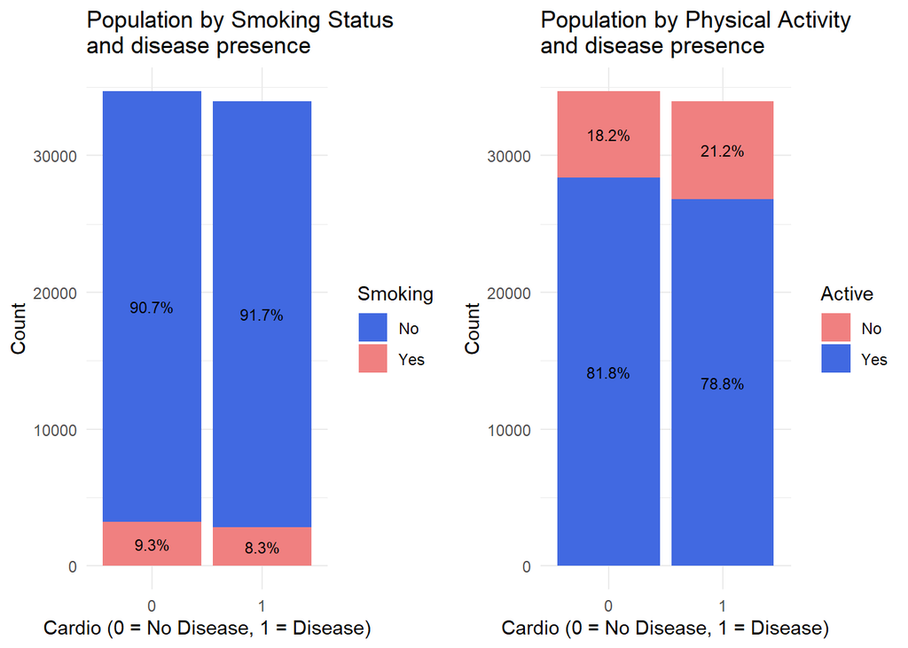

```r
smoke_active = grid.arrange(pSmoke, pActive, ncol = 2)
```

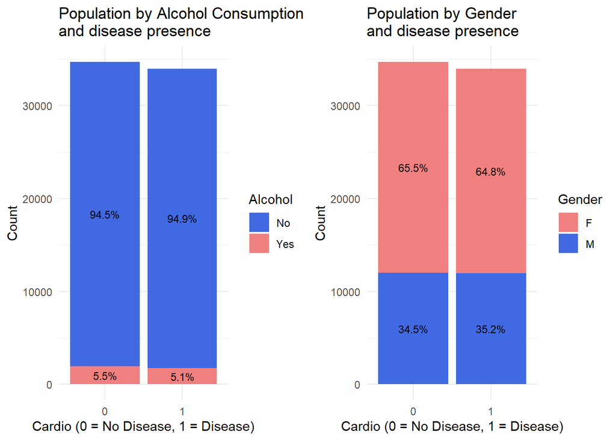

```r
alcohol_gender = grid.arrange(pAlco, pGender, ncol = 2)
```

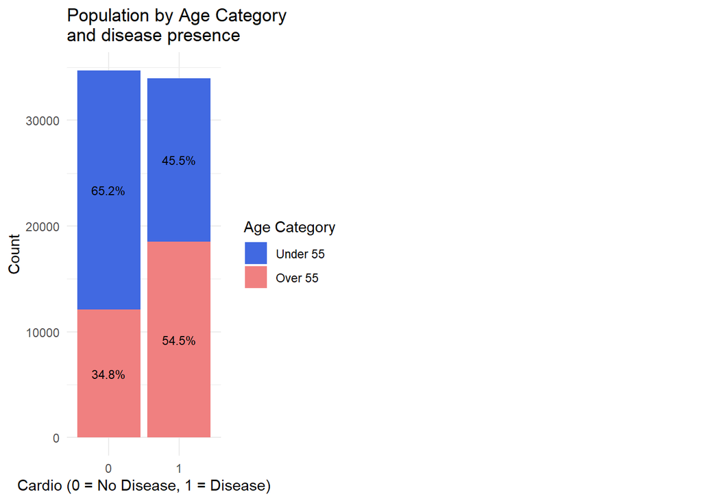

```r
age_cat_barplot = grid.arrange(pAgeCat, ncol = 2)
```

```r
# saving barplots
cg <- arrangeGrob(pChol, pGluc, ncol = 2)
sa <- arrangeGrob(pSmoke, pActive, ncol = 2)
ag <- arrangeGrob(pAlco, pGender, ncol = 2)
acat <- arrangeGrob(pAgeCat, ncol = 1)
ggsave("images/chol_gluc.png", cg, width = 8, height = 8)
ggsave("images/smoke_active.png", sa, width = 8, height = 8)
ggsave("images/alcohol_gender.png", ag, width = 8, height = 8)
ggsave("images/agecat.png", acat, width = 8, height = 8)
```

Within people having heart a disease, high cholesterol, glucose and older age people are significantly overrepresented, and to a smaller extent are also inactive people. Surprisingly, the percentage of smokers and alcohol consumers is slightly higher for the healthy group, whereas gender doesn’t seem to have significant differences.

### Correlation analysis

The following heatmap confirms some (perhaps rather intuitive) relationships:

- Diastolic (`ap_lo`) and systolic (`ap_hi`) blood pressure are heavily correlated
- Both `weight` and `age` are positively correlated with higher diastolic and systolic blood pressure, the former slightly more than the latter.

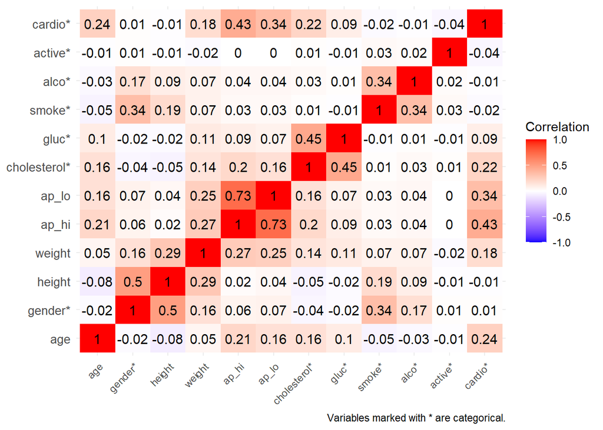

```r
cor_cardio <- round(cor(as.data.frame(cardio_cl)), 2)

melt_cardio <- melt(cor_cardio, na.rm = TRUE)
labels <- c(
  "age","gender*", "height", "weight", "ap_hi", "ap_lo", "cholesterol*", "gluc*", "smoke*", "alco*", "active*", "cardio*")
corr_heatmap<- ggplot(data = melt_cardio, aes(x = Var1, y = Var2, fill = value)) +
  geom_tile() +
  geom_text(aes(label = value), size = 4) +
  scale_fill_gradient2(low = "blue", high = "red", limit = c(-1, 1), name = "Correlation") +
  scale_x_discrete(labels = labels) +
  scale_y_discrete(labels = labels) +
  theme_minimal() +  labs(caption = "Variables marked with * are categorical.") +
  theme(
    axis.title.x = element_blank(),
    axis.title.y = element_blank(),
    axis.text.x = element_text(angle = 45, vjust = 1, hjust = 1),
    axis.text.y = element_text(size = 10)
  )

corr_heatmap
```

```r
ggsave("images/corrheatmap.png", corr_heatmap, width = 8, height = 8)
```

We use the Chi-squared test to see to which degree the variables are correlated with `cardio`:

```r
categorical_vars <- names(categorical)[names(categorical) != "cardio"]
test_results <- list()

for (var in categorical_vars) {
  test <- chisq.test(table(cardio$cardio, cardio[[var]]))
  test_results[[var]] <- test
}

for (var in categorical_vars) {
  cat("Chi-Squared Test for", var, ":\n")
  print(test_results[[var]])
  cat("\n")
}
```

```
## Chi-Squared Test for gender :
##
##  Pearson's Chi-squared test with Yates' continuity correction
##
## data:  table(cardio$cardio, cardio[[var]])
## X-squared = 3.4815, df = 1, p-value = 0.06206
##
##
## Chi-Squared Test for cholesterol :
##
##  Pearson's Chi-squared test
##
## data:  table(cardio$cardio, cardio[[var]])
## X-squared = 3367.6, df = 2, p-value < 2.2e-16
##
##
## Chi-Squared Test for gluc :
##
##  Pearson's Chi-squared test
##
## data:  table(cardio$cardio, cardio[[var]])
## X-squared = 579.43, df = 2, p-value < 2.2e-16
##
##
## Chi-Squared Test for smoke :
##
##  Pearson's Chi-squared test with Yates' continuity correction
##
## data:  table(cardio$cardio, cardio[[var]])
## X-squared = 18.174, df = 1, p-value = 2.016e-05
##
##
## Chi-Squared Test for alco :
##
##  Pearson's Chi-squared test with Yates' continuity correction
##
## data:  table(cardio$cardio, cardio[[var]])
## X-squared = 5.132, df = 1, p-value = 0.02349
##
##
## Chi-Squared Test for active :
##
##  Pearson's Chi-squared test with Yates' continuity correction
##
## data:  table(cardio$cardio, cardio[[var]])
## X-squared = 95.725, df = 1, p-value < 2.2e-16
##
##
## Chi-Squared Test for age_cat :
##
##  Pearson's Chi-squared test with Yates' continuity correction
##
## data:  table(cardio$cardio, cardio[[var]])
## X-squared = 2692.2, df = 1, p-value < 2.2e-16
```

```r
significant_vars <- names(test_results)[sapply(test_results, function(x) x$p.value < 0.05)]
cat("Variables with significant association (p < 0.05):\n")
```

```
## Variables with significant association (p < 0.05):
```

```r
print(significant_vars)
```

```
## [1] "cholesterol" "gluc"        "smoke"       "alco"        "active"
## [6] "age_cat"
```

We see that all of the available categorical variables, besides `gender`, seem to be very relevant in determining the insurgence of heart diseases.

Let’s now test the mean differences between groups for diastolic and systolic blood pressure. We perform t-tests for binary variables, and ANOVA tests for groups of more than two.

```r
continuous_vars = c("ap_hi", "ap_lo", "weight", "height", "age")

test_mean_diff = function(continuous_vars, categorical_vars){
  mean_diff_results <- data.frame(
    Variable = character(),
    Group = character(),
    Test = character(),
    P_Value = numeric(),
    stringsAsFactors = FALSE
)
  for (cont_var in continuous_vars) {
  for (cat_var in categorical_vars) {
    num_levels = length(unique(cardio[, cat_var]))
    if (num_levels == 2) {
      # Perform t-test
      t_test = t.test(cardio[, cont_var] ~ cardio[, cat_var])
      p_value = t_test$p.value
      test_type = "t-test"
    } else {
      # Perform ANOVA
      anova_test = aov(cardio[, cont_var] ~ cardio[, cat_var])
      p_value = summary(anova_test)[[1]][["Pr(>F)"]][1]
      p_value = 0.0001
      test_type = "ANOVA"
    }
    # Append results
    results = data.frame(
                                Variable = cont_var,
                                Group = cat_var,
                                Test = test_type,
                                P_Value = p_value
                              )
    mean_diff_results = bind_rows(mean_diff_results, results)
  }
  }
return(mean_diff_results)
  }

# View results
result = test_mean_diff(continuous_vars, categorical_vars)
print(result)
```

```
##    Variable       Group   Test       P_Value
## 1     ap_hi      gender t-test  3.145876e-60
## 2     ap_hi cholesterol  ANOVA  1.000000e-04
## 3     ap_hi        gluc  ANOVA  1.000000e-04
## 4     ap_hi       smoke t-test  3.079389e-12
## 5     ap_hi        alco t-test  9.480653e-18
## 6     ap_hi      active t-test  7.736176e-01
## 7     ap_hi     age_cat t-test  0.000000e+00
## 8     ap_lo      gender t-test  3.089446e-71
## 9     ap_lo cholesterol  ANOVA  1.000000e-04
## 10    ap_lo        gluc  ANOVA  1.000000e-04
## 11    ap_lo       smoke t-test  5.627022e-11
## 12    ap_lo        alco t-test  1.362614e-19
## 13    ap_lo      active t-test  8.530274e-01
## 14    ap_lo     age_cat t-test 8.191445e-219
```

[output cut: 21 more lines]

Once again, there definitely are some significant differences between the groups considered.

```r
custom_colors <- c("darkviolet","orange", "#228b22")

# Function to create plots
create_plot <- function(color_var) {
  ggplot(cardio, aes(cardio, ap_hi)) +
    geom_boxplot(aes(color = !!sym(color_var))) +
    scale_color_manual(values = custom_colors) + theme_minimal()
}

# Generate plots
p1 <- create_plot("cholesterol")
p2 <- create_plot("age_cat")
p3 <- create_plot("smoke")
p4 <- create_plot("active")
p5 <- create_plot("alco")
p6 <- create_plot("gluc")
```

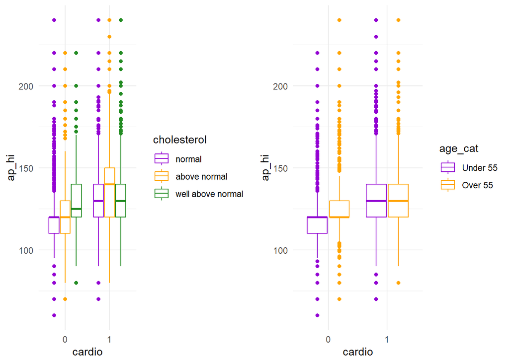

```r
grid.arrange(p1, p2, ncol = 2)
```

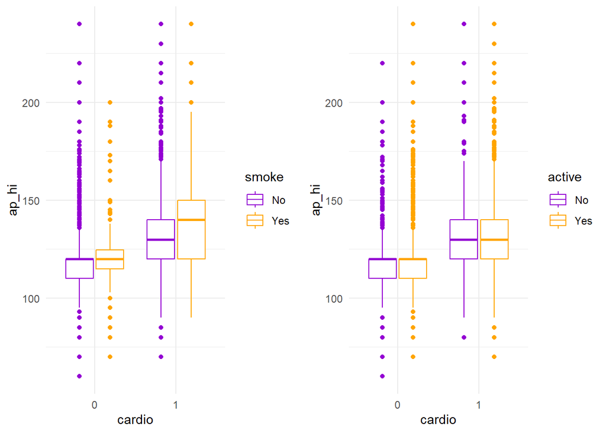

```r
grid.arrange(p3, p4, ncol = 2)
```

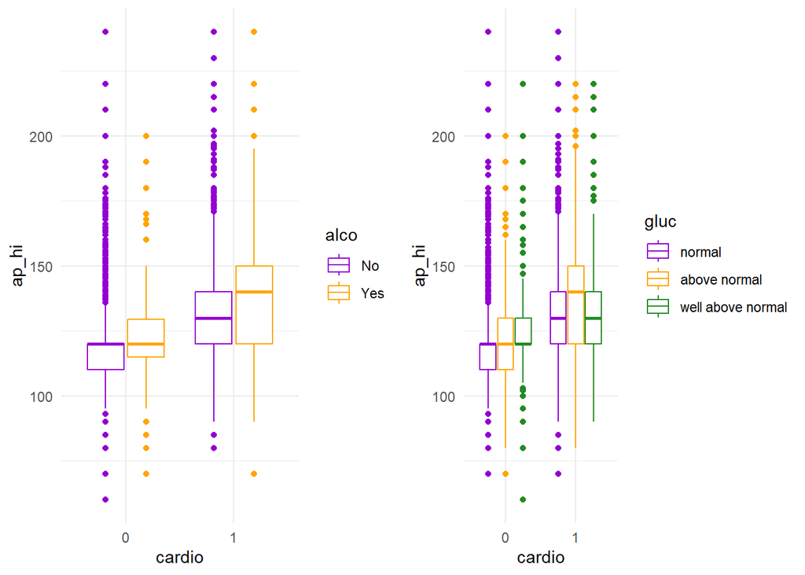

```r
grid.arrange(p5, p6, ncol = 2)
```

```r
first4cat = arrangeGrob(p1, p2, p3, p4, ncol=2)
second2cat = arrangeGrob(p5, p6, ncol=2)

ggsave("images/APHI_chol_age_smoke_active.png", first4cat, width = 8, height = 8)
ggsave("images/APHIalco_gluc.png", second2cat, width = 8, height = 8)
```

While no group shows a clean division with respect to `cardio`, values of both `gluc` and `cholesterol` *above normal* or *well above normal* seem to be particularly frequent along with the occurrence of heart diseases.

## Cluster analysis

We proceed by performing cluster analysis. Due to the nature of data, and various experiments with the results, we considered two different approaches:

- Considering all the variables, but scaling just the numerical ones.
- Scaling and considering just numerical variables.

### K-means clustering (all variables)

```r
# Filter the dataset to exclude these columns and scale the remaining numeric columns
cardio_scaled_onlynums = cardio_cl
cardio_scaled_onlynums[, c(continuous_vars)] = scale(cardio_scaled_onlynums[, c(continuous_vars)])

# View the first few rows of the dataset
head(cardio_scaled_onlynums)
```

|  | age | gender | height | weight | ap_hi | ap_lo | cholesterol | gluc | smoke | alco | active | cardio |
| --- | --- | --- | --- | --- | --- | --- | --- | --- | --- | --- | --- | --- |
| 1 | -0.4340998 | 2 | 0.44466457 | -0.8455257 | -0.9985899 | -0.1346190 | 1 | 1 | 0 | 0 | 1 | 0 |
| 2 | 0.3093803 | 1 | -1.02172210 | 0.7593791 | 0.7980078 | 0.9144636 | 3 | 1 | 0 | 0 | 1 | 1 |
| 3 | -0.2461027 | 1 | 0.07806791 | -0.7059688 | 0.1991419 | -1.1837015 | 3 | 1 | 0 | 0 | 0 | 1 |
| 4 | -0.7460778 | 2 | 0.56686346 | 0.5500436 | 1.3968737 | 1.9635462 | 1 | 1 | 0 | 0 | 1 | 1 |
| 5 | -0.8064476 | 1 | -1.02172210 | -1.2641966 | -1.5974557 | -2.2327841 | 1 | 1 | 0 | 0 | 0 | 0 |
| 6 | 0.9924906 | 1 | -1.63271655 | -0.4966334 | -0.3997240 | -0.1346190 | 2 | 2 | 0 | 0 | 0 | 0 |

```r
# Compute the distance matrix for the scaled data
sample_cardio_onlynums = sample(as.matrix(cardio_scaled_onlynums), 10000)
dist_matrix <- dist(sample_cardio_onlynums)
```

```r
# Perform K-means clustering
set.seed(123)
silhouette_scores_onlynum = c()

# Try out different numbers of clustering and see which one has the highest silhouette score (meaning it best divides the data)
# Due to computational constraints we select just a subset of the original observations, 1/7, to tune this hyperparameter
 for (n_clusters in 2:10) {
   # Perform k-means clustering
   kmeans_result <- kmeans(sample_cardio_onlynums, centers = n_clusters)

   # Extract cluster labels from the k-means result
   cluster_labels <- kmeans_result$cluster

   # Calculate silhouette values
   sil <- silhouette(cluster_labels, dist_matrix)

   # Store the average silhouette score for the current number of clusters
   silhouette_scores_onlynum[n_clusters] <- mean(sil[, 3])
 }

max_silhouette_kmeans_onlynum = which.max(silhouette_scores_onlynum)

best_kmeans_result_onlynum <- kmeans(cardio_cl, centers = max_silhouette_kmeans_onlynum)
# Add the cluster assignment to the original data
cardio$Cluster_ON <- as.factor(best_kmeans_result_onlynum$cluster)
table(cardio$Cluster_ON)
```

```
##
##     1     2     3     4     5     6     7     8     9    10
##  5222  3339  5271  7301 11511 10351  2176  6932  9100  7496
```

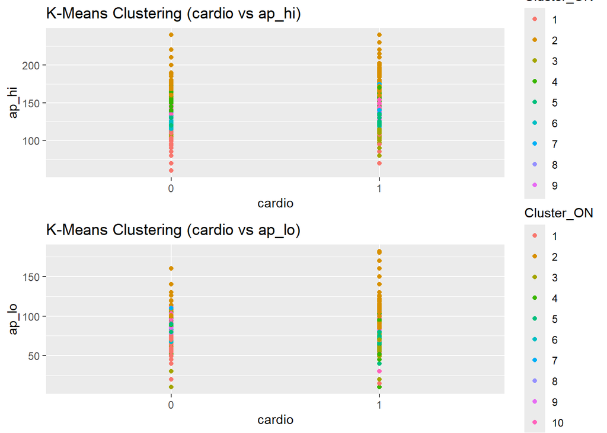

```r
# Visualize the clusters across different dimensions
cl_p1 = ggplot(cardio, aes(cardio, ap_hi, color = Cluster_ON)) +
  geom_point() +
  labs(title = "K-Means Clustering (cardio vs ap_hi)")
cl_p2 = ggplot(cardio, aes(cardio, ap_lo, color = Cluster_ON)) +
  geom_point() +
  labs(title = "K-Means Clustering (cardio vs ap_lo)")

grid.arrange(cl_p1, cl_p2)
```

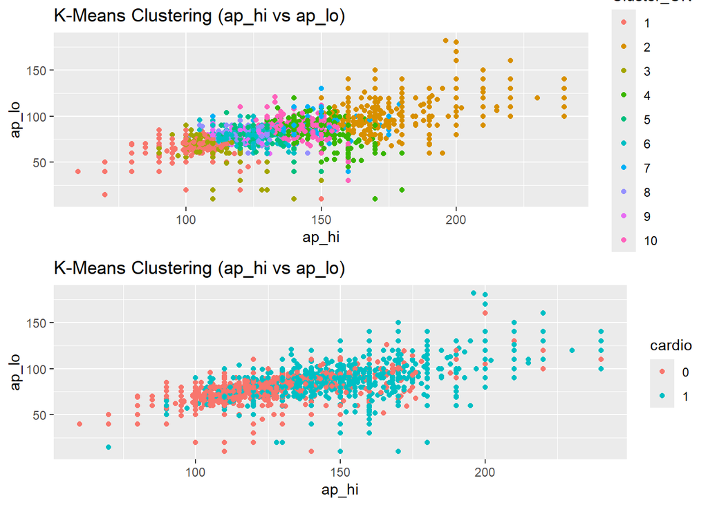

```r
cl_p3 = ggplot(cardio, aes(ap_hi, ap_lo, color = Cluster_ON)) +
  geom_point() +
  labs(title = "K-Means Clustering (ap_hi vs ap_lo)")
cardio_pl = ggplot(cardio, aes(ap_hi, ap_lo, color = cardio)) +
  geom_point() +
  labs(title = "K-Means Clustering (ap_hi vs ap_lo)")
grid.arrange(cl_p3, cardio_pl)
```

There is a split, but a lot of clusters overlap for central values.

```r
cluster_summary_ON <- cardio %>%
  group_by(Cluster_ON) %>%
  summarize(
    Count = n(),
    disease_incidence = sum(cardio == 1)/n(),
    active_count = sum(active == "Yes")/n(),
    high_chol = sum(cholesterol %in% c("above normal", "well above normal"))/n(),
    gluc = sum(gluc %in% c("above normal", "well above normal"))/n(),
    ap_hi = mean(ap_hi),
    ap_lo = mean(ap_lo),
    Female = sum(gender == "F") / n(),
    Male = sum(gender == "M") / n()
    # Add more summary statistics as needed
  )
cluster_summary_ON
```

| Cluster_ON | Count | disease_incidence | active_count | high_chol | gluc | ap_hi | ap_lo | Female | Male |
| --- | --- | --- | --- | --- | --- | --- | --- | --- | --- |
| 1 | 5222 | 0.1756032 | 0.8215243 | 0.1656453 | 0.09383378 | 104.6519 | 67.40655 | 0.8433550 | 0.1566450 |
| 2 | 3339 | 0.8637317 | 0.8038335 | 0.4339623 | 0.23539982 | 168.6062 | 97.77957 | 0.5929919 | 0.4070081 |
| 3 | 5271 | 0.2631379 | 0.8104724 | 0.1830772 | 0.12198824 | 107.3445 | 69.11535 | 0.6602163 | 0.3397837 |
| 4 | 7301 | 0.8279688 | 0.8182441 | 0.3444734 | 0.16216957 | 145.0734 | 88.47459 | 0.7356527 | 0.2643473 |
| 5 | 11511 | 0.4932673 | 0.7959343 | 0.2251759 | 0.14672922 | 122.7746 | 80.42872 | 0.6492051 | 0.3507949 |
| 6 | 10351 | 0.3764854 | 0.8003091 | 0.1881944 | 0.12153415 | 121.0983 | 80.04579 | 0.8119988 | 0.1880012 |
| 7 | 2176 | 0.7715993 | 0.7853860 | 0.4480699 | 0.30055147 | 142.8640 | 89.20267 | 0.5340074 | 0.4659926 |
| 8 | 6932 | 0.4552799 | 0.7921235 | 0.2654357 | 0.17830352 | 121.1867 | 79.54833 | 0.5145701 | 0.4854299 |
| 9 | 9100 | 0.2579121 | 0.8014286 | 0.1209890 | 0.08703297 | 120.1537 | 79.67560 | 0.5175824 | 0.4824176 |
| 10 | 7496 | 0.8001601 | 0.8046958 | 0.3904749 | 0.20731057 | 140.9923 | 89.43183 | 0.5601654 | 0.4398346 |

### K-means clustering (numerical variables)

```r
cardio_justnum <- scale(cardio_cl[, continuous_vars])

# View the first few rows of the dataset
head(cardio_justnum)
```

```
##        ap_hi      ap_lo     weight      height        age
## 1 -0.9985899 -0.1346190 -0.8455257  0.44466457 -0.4340998
## 2  0.7980078  0.9144636  0.7593791 -1.02172210  0.3093803
## 3  0.1991419 -1.1837015 -0.7059688  0.07806791 -0.2461027
## 4  1.3968737  1.9635462  0.5500436  0.56686346 -0.7460778
## 5 -1.5974557 -2.2327841 -1.2641966 -1.02172210 -0.8064476
## 6 -0.3997240 -0.1346190 -0.4966334 -1.63271655  0.9924906
```

```r
# Compute the distance matrix for the scaled data
sample_justnum = sample(cardio_justnum, 10000)
dist_matrix_justnum <- dist(sample_justnum)
```

```r
# Perform K-means clustering
set.seed(123)
silhouette_scores_justnum = c()

# Try out different numbers of clustering and see which one has the highest silhouette score (meaning it best divides the data)
# Due to computational constraints we select just a subset of the original observations, 1/7, to tune this hyperparameter
 for (n_clusters in 2:10) {
   # Perform k-means clustering
   kmeans_result <- kmeans(sample_justnum, centers = n_clusters)

   # Extract cluster labels from the k-means result
   cluster_labels <- kmeans_result$cluster

   # Calculate silhouette values
   sil <- silhouette(cluster_labels, dist_matrix)

   # Store the average silhouette score for the current number of clusters
   silhouette_scores_justnum[n_clusters] <- mean(sil[, 3])
 }

max_silhouette_kmeans_justnum = which.max(silhouette_scores_justnum)

best_kmeans_result_justnum <- kmeans(cardio_justnum, centers = max_silhouette_kmeans_justnum)
# Add the cluster assignment to the original data
cardio$Cluster <- as.factor(best_kmeans_result_justnum$cluster)
table(cardio$Cluster)
```

```
##
##     1     2
## 45200 23499
```

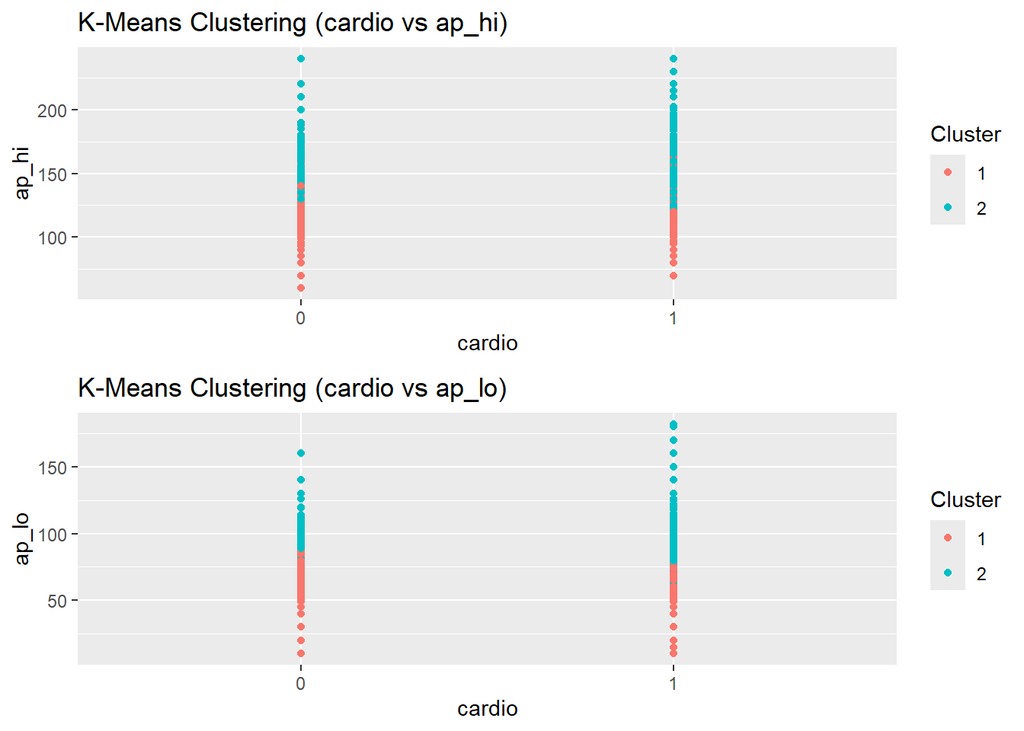

```r
# Visualize the clusters across different dimensions
cl_p1 = ggplot(cardio, aes(cardio, ap_hi, color = Cluster)) +
  geom_point() +
  labs(title = "K-Means Clustering (cardio vs ap_hi)")
cl_p2 = ggplot(cardio, aes(cardio, ap_lo, color = Cluster)) +
  geom_point() +
  labs(title = "K-Means Clustering (cardio vs ap_lo)")

grid.arrange(cl_p1, cl_p2)
```

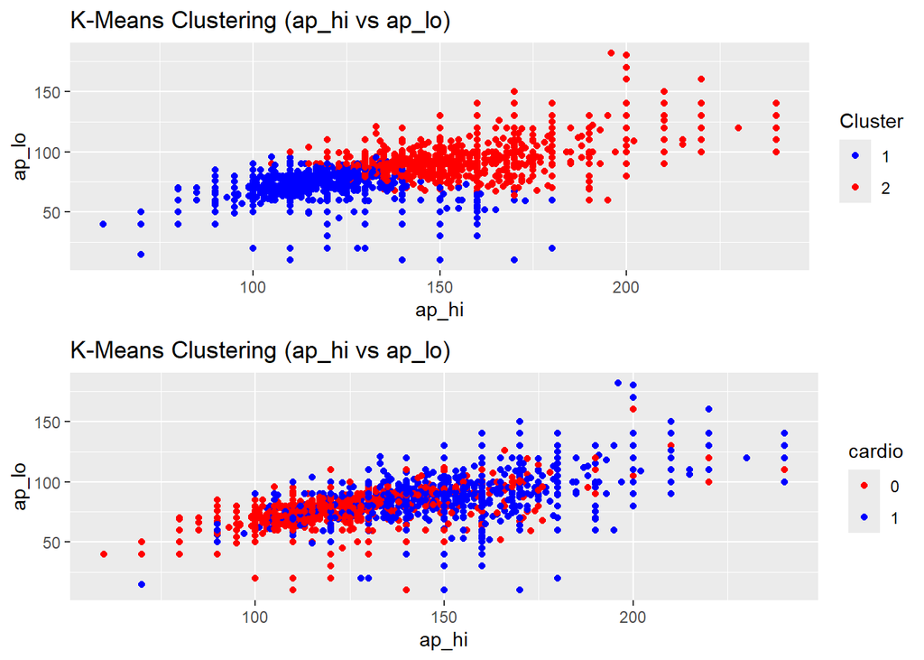

```r
cl_p3 = ggplot(cardio, aes(ap_hi, ap_lo, color = Cluster)) +
  geom_point() +
  scale_color_manual(values = c("1" = "blue", "2" = "red")) + # Invert cluster colors
  labs(title = "K-Means Clustering (ap_hi vs ap_lo)", color = "Cluster")
cardio_pl = ggplot(cardio, aes(ap_hi, ap_lo, color = cardio)) +
  geom_point() +
  scale_color_manual(values = c("0" = "red", "1" = "blue")) + # Invert cluster colors
  labs(title = "K-Means Clustering (ap_hi vs ap_lo)")
grid.arrange(cl_p3, cardio_pl)
```

```r
ggsave("images/2kmodes_justnum_good.png", width=8, height=6)
```

```r
info_cluster1 = cardio %>% filter(Cluster == 1)
summary(info_cluster1)
```

```
##       age        gender        height          weight           ap_hi
##  Min.   :29.58   F:30478   Min.   : 57.0   Min.   : 11.00   Min.   : 60.0
##  1st Qu.:47.35   M:14722   1st Qu.:159.0   1st Qu.: 62.00   1st Qu.:110.0
##  Median :52.42             Median :165.0   Median : 69.00   Median :120.0
##  Mean   :52.23             Mean   :164.1   Mean   : 69.95   Mean   :117.8
##  3rd Qu.:57.77             3rd Qu.:169.0   3rd Qu.: 77.00   3rd Qu.:120.0
##  Max.   :64.97             Max.   :207.0   Max.   :141.00   Max.   :180.0
##
##      ap_lo                   cholesterol                   gluc
##  Min.   : 10.00   normal           :36967   normal           :39774
##  1st Qu.: 70.00   above normal     : 4871   above normal     : 2602
##  Median : 80.00   well above normal: 3362   well above normal: 2824
##  Mean   : 76.69
##  3rd Qu.: 80.00
##  Max.   :100.00
##
##  smoke        alco       active      cardio        age_cat        Cluster_ON
##  No :41531   No :43108   No : 8883   0:29530   Under 55:28109   6      :10042
##  Yes: 3669   Yes: 2092   Yes:36317   1:15670   Over 55 :17091   5      : 9831
##                                                                 9      : 8940
##                                                                 3      : 5271
##                                                                 1      : 5222
##                                                                 8      : 4747
##                                                                 (Other): 1147
##  Cluster
##  1:45200
##  2:    0
##
##
##
##
##
```

```r
info_cluster2 = cardio %>% filter(Cluster == 2)
summary(info_cluster2)
```

```
##       age        gender        height          weight           ap_hi
##  Min.   :39.11   F:14273   Min.   : 55.0   Min.   : 35.00   Min.   :100.0
##  1st Qu.:51.65   M: 9226   1st Qu.:159.0   1st Qu.: 70.00   1st Qu.:130.0
##  Median :56.10             Median :165.0   Median : 80.00   Median :140.0
##  Mean   :55.44             Mean   :164.9   Mean   : 82.14   Mean   :143.8
##  3rd Qu.:60.16             3rd Qu.:170.0   3rd Qu.: 91.00   3rd Qu.:150.0
##  Max.   :64.90             Max.   :250.0   Max.   :200.00   Max.   :240.0
##
##      ap_lo                   cholesterol                   gluc
##  Min.   : 60.00   normal           :14555   normal           :18639
##  1st Qu.: 90.00   above normal     : 4434   above normal     : 2467
##  Median : 90.00   well above normal: 4510   well above normal: 2393
##  Mean   : 90.11
##  3rd Qu.: 90.00
##  Max.   :182.00
##
##  smoke        alco       active      cardio        age_cat        Cluster_ON
##  No :21127   No :21926   No : 4625   0: 5181   Under 55: 9968   10     :7377
##  Yes: 2372   Yes: 1573   Yes:18874   1:18318   Over 55 :13531   4      :6281
##                                                                 2      :3339
##                                                                 8      :2185
##                                                                 7      :2168
##                                                                 5      :1680
##                                                                 (Other): 469
##  Cluster
##  1:    0
##  2:23499
##
##
##
##
##
```

```r
# Group the data by Cluster and calculate summary statistics
cluster_summary <- cardio %>%
  group_by(Cluster) %>%
  summarize(
    Count = n(),
    disease_incidence = sum(cardio == 1)/n(),
    active_count = sum(active == "Yes")/n(),
    high_chol = sum(cholesterol %in% c("above normal", "well above normal"))/n(),
    gluc = sum(gluc %in% c("above normal", "well above normal"))/n(),
    Female = sum(gender == "F") / n(),
    Male = sum(gender == "M") / n(),
    ap_hi = mean(ap_hi),
    ap_lo = mean(ap_lo),
    # Add more summary statistics as needed
  )

# Print the summary table
print(cluster_summary)
```

```
## # A tibble: 2 × 10
##   Cluster Count disease_incidence active_count high_chol  gluc Female  Male
##   <fct>   <int>             <dbl>        <dbl>     <dbl> <dbl>  <dbl> <dbl>
## 1 1       45200             0.347        0.803     0.182 0.120  0.674 0.326
## 2 2       23499             0.780        0.803     0.381 0.207  0.607 0.393
## # ℹ 2 more variables: ap_hi <dbl>, ap_lo <dbl>
```

```r
cardio$Cluster <- NULL
cardio$Cluster_ON <- NULL
cardio$age_cat <- NULL
```

## Random Forest

### Classification trees

In order to correctly fit the random forest model, let’s analyze first some simpler classifiers: classification trees.

For this models, as well as for the following ones, dataset will be split in two parts: 80% for training the model and 20% for testing.

```r
# Split data (train/test)
set.seed(123)
train_index <- sample(1:nrow(cardio), 0.8 * nrow(cardio))
train_data <- cardio[train_index, ]
test_data <- cardio[-train_index, ]
```

Now, it is time to fit the model. The function `rpart`, expects some user-defined parameters (the ones passed to the function below) but can also accept multiple optional parameters like `rpart.control`. This one controls some of the characteristic of the tree:

- `minsplit`: Minimum observations to attempt a split.
- `cp`: Complexity parameter for pruning.
- `maxdepth`: Maximum depth of the tree
- …

```r
# Build and plot the classification tree
tree <- rpart(cardio ~ ., data = train_data, method = "class")
tree$control
```

```
## $minsplit
## [1] 20
##
## $minbucket
## [1] 7
##
## $cp
## [1] 0.01
##
## $maxcompete
## [1] 4
##
## $maxsurrogate
## [1] 5
##
## $usesurrogate
## [1] 2
##
## $surrogatestyle
## [1] 0
##
## $maxdepth
## [1] 30
##
## $xval
## [1] 10
```

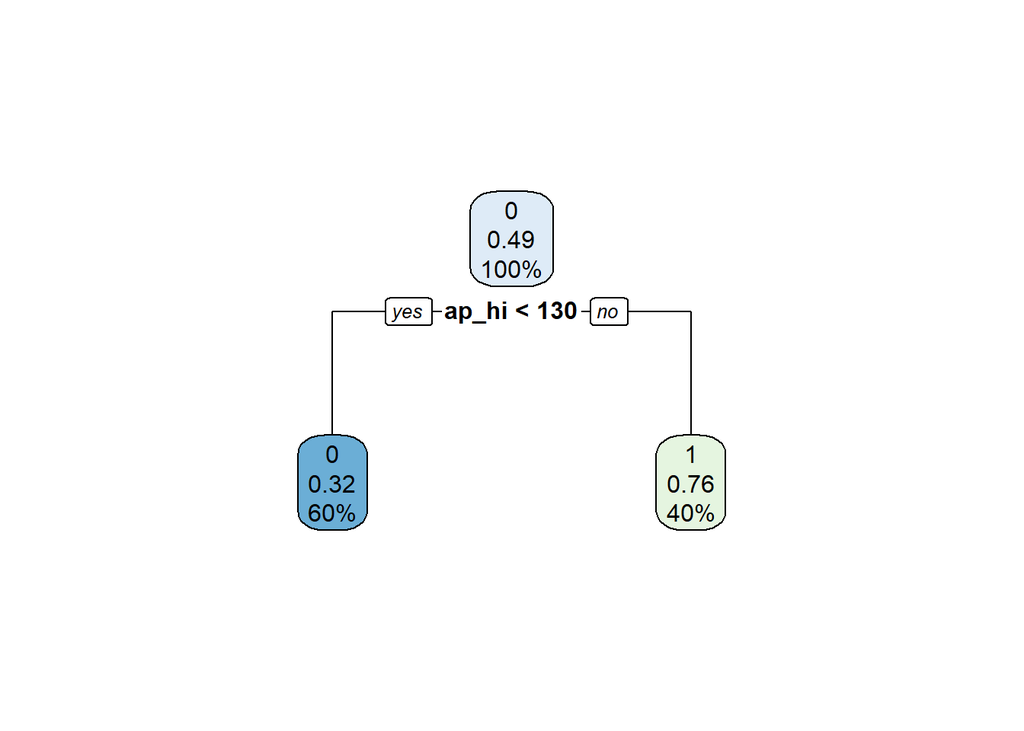

```r
rpart.plot(tree)
```

```r
# Save image
png("images/high_cp_tree_plot.png", width = 800, height = 600)
rpart.plot(tree)
dev.off()
```

At first sight, we can observe that the classification tree completely relies on the feature `ap_hi` for the only split. Let’s check the importance of the different features in the model:

```r
# Check feature importance
tree$variable.importance
```

```
##       ap_hi       ap_lo cholesterol      weight         age        gluc
##   5030.0003   3009.0444    574.1688    551.6657    211.6196    110.4695
```

It seem that `ap_hi`, together with `ap_lo`, out stand over the others features. Even though both of them are significant, they are highly correlated, so taking them into account at the same time would introduce redundancy in the tree.

In order to better understand the performance of this model, we can check its accuracy and the area under the ROC curve after trying to classify the testing data.

```r
# Make predictions
predictions <- predict(tree, test_data, type = "prob")

# Convert probabilities to predicted classes
predicted_classes <- ifelse(predictions[, 2] > 0.5, 1, 0)

# Confusion matrix
confusion_matrix <- table(Predicted = predicted_classes, Actual = test_data$cardio)
confusion_matrix
```

```
##          Actual
## Predicted    0    1
##         0 5639 2524
##         1 1296 4281
```

```r
# Accuracy
accuracy <- sum(diag(confusion_matrix)) / sum(confusion_matrix)
print(paste("Accuracy:", round(accuracy * 100, 2), "%"))
```

```
## [1] "Accuracy: 72.2 %"
```

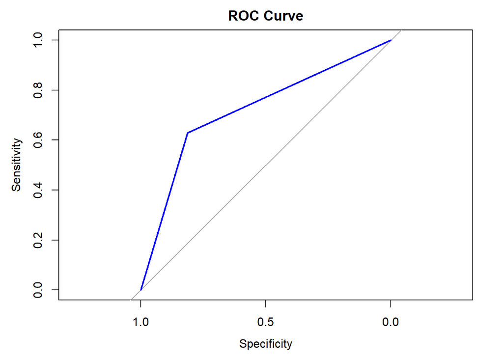

```r
# ROC curve
roc_curve <- roc(test_data$cardio, predictions[, 2])
plot(roc_curve, main = "ROC Curve", col = "blue", lwd = 2)
```

```r
# AUC
auc_value <- auc(roc_curve)
print(paste("AUC:", round(auc_value, 4)))
```

```
## [1] "AUC: 0.7211"
```

```r
# Save image
png("images/high_cp_roc_curve.png", width = 800, height = 600)
plot(roc_curve, main = "ROC Curve", col = "blue", lwd = 2)
dev.off()
```

Could we improve the performance of the model with more splits? In order to force the tree to use less relevant features, we will readjust the complexity parameter (`cp`).

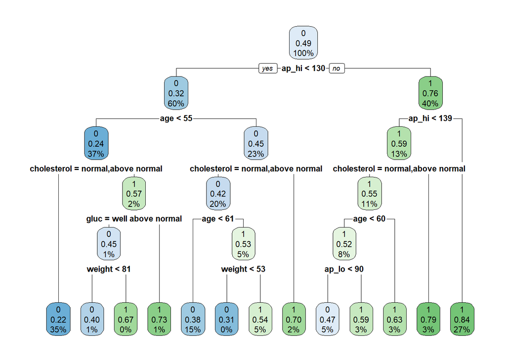

```r
# New classification tree
tree <- rpart(cardio ~ ., data = train_data, method = "class",
              control = rpart.control(cp = 0.001))
rpart.plot(tree)
```

```r
# Save image
png("images/low_cp_tree_plot.png", width = 800, height = 600)
rpart.plot(tree)
dev.off()
```

```r
# Check feature importance
tree$variable.importance
```

```
##       ap_hi       ap_lo cholesterol         age      weight        gluc
## 5613.648685 3134.154441 1121.568555 1019.007613  579.822704  230.683377
##      height       smoke
##    3.151431    1.330961
```

Let’s check the performance:

```r
# Make predictions
predictions <- predict(tree, test_data, type = "prob")

# Convert probabilities to predicted classes
predicted_classes <- ifelse(predictions[, 2] > 0.5, 1, 0)

# Confusion matrix
confusion_matrix <- table(Predicted = predicted_classes, Actual = test_data$cardio)
confusion_matrix
```

```
##          Actual
## Predicted    0    1
##         0 5477 2168
##         1 1458 4637
```

```r
# Accuracy
accuracy <- sum(diag(confusion_matrix)) / sum(confusion_matrix)
print(paste("Accuracy:", round(accuracy * 100, 2), "%"))
```

```
## [1] "Accuracy: 73.61 %"
```

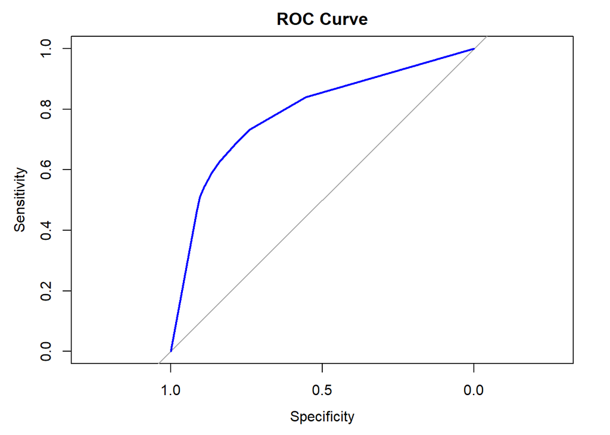

```r
# ROC curve
roc_curve <- roc(test_data$cardio, predictions[, 2])
plot(roc_curve, main = "ROC Curve", col = "blue", lwd = 2)
```

```r
# AUC
auc_value <- auc(roc_curve)
print(paste("AUC:", round(auc_value, 4)))
```

```
## [1] "AUC: 0.7853"
```

```r
# Save image
png("images/low_cp_roc_curve.png", width = 800, height = 600)
plot(roc_curve, main = "ROC Curve", col = "blue", lwd = 2)
dev.off()
```

After evaluating both models, we get a sightly better accuracy from a significantly more complex tree. Moreover, the area under the ROC curve also increases. From this comparison, we can conclude that although the blood pressure is one the best indicators (in this dataset) of cardiovascular diseases, observing other variables like cholesterol, weight, age or glucose also helps to identify them.

### Model

Following classification trees, a natural approximation is fitting a random forest model.

Since the trees that make up the model are completely independent and in order to speed up the training, the problem may be parallelized. Let’s set it up:

```r
# Detect the number of cores available on your machine and register them
cores <- parallel::detectCores()
cl <- makeCluster(cores)  # Create a cluster with the detected cores
registerDoParallel(cl)    # Register the parallel backend
```

For this model, instead of splitting the data in two as we previously did, we will apply a k-fold-cross-validation technique. As this is going to be one of the final classifiers, correctly evaluating its performance and fully using the dataset for both training and validation is of vital importance.

Many parameters can be configured here. Some of them are:

- `trControl(folds)`: The number of folds for the cross validation.
- `tuneGrid(mtry)`: The number of features to use in each decision tree.
- `tuneGrid(splitrule)`: Rule for splitting the tree
- `tuneGrid(min.node.size)`: Minimum number of observations per leaf node.
- …

After testing and analyzing all type of combination, the one which provided the best area under the ROC curve was the following one:

```r
# Cross-validation setup
train_control <- trainControl(
  method = "cv",
  number = 5,           # Folds
  classProbs = TRUE,     # Enable probabilities
  summaryFunction = twoClassSummary
)

tune <- expand.grid(
    mtry = c(2),
    splitrule = c("gini"),
    min.node.size = c(1)
)
```

Finally, let’s compute the random forest using our settings.

```r
# Factorize the variable if it is not a factor
train_data$cardio <- factor(train_data$cardio, levels = c(0, 1), labels = c("No", "Yes"))

rf_model <- train(
  cardio ~ .,
  data = train_data,
  method = "ranger",
  trControl = train_control,
  tuneGrid = tune,
  metric = "ROC"
)

# Free resources
stopCluster(cl)
unregister_dopar <- function() {
  env <- foreach:::.foreachGlobals
  rm(list=ls(name=env), pos=env)
}
unregister_dopar()

# Final model
print(rf_model)
```

```
## Random Forest
##
## 54959 samples
##    11 predictor
##     2 classes: 'No', 'Yes'
##
## No pre-processing
## Resampling: Cross-Validated (5 fold)
## Summary of sample sizes: 43967, 43967, 43968, 43967, 43967
## Resampling results:
##
##   ROC        Sens       Spec
##   0.7974194  0.7896024  0.674245
##
## Tuning parameter 'mtry' was held constant at a value of 2
## Tuning
##  parameter 'splitrule' was held constant at a value of gini
## Tuning
##  parameter 'min.node.size' was held constant at a value of 1
```

### Performance

Regarding the performance of the final model:

```r
# General results
rf_model$results
```

|  | mtry | splitrule | min.node.size | ROC | Sens | Spec | ROCSD | SensSD | SpecSD |
| --- | --- | --- | --- | --- | --- | --- | --- | --- | --- |
| 1 | 2 | gini | 1 | 0.7974194 | 0.7896024 | 0.674245 | 0.006228104 | 0.006909411 | 0.007128497 |

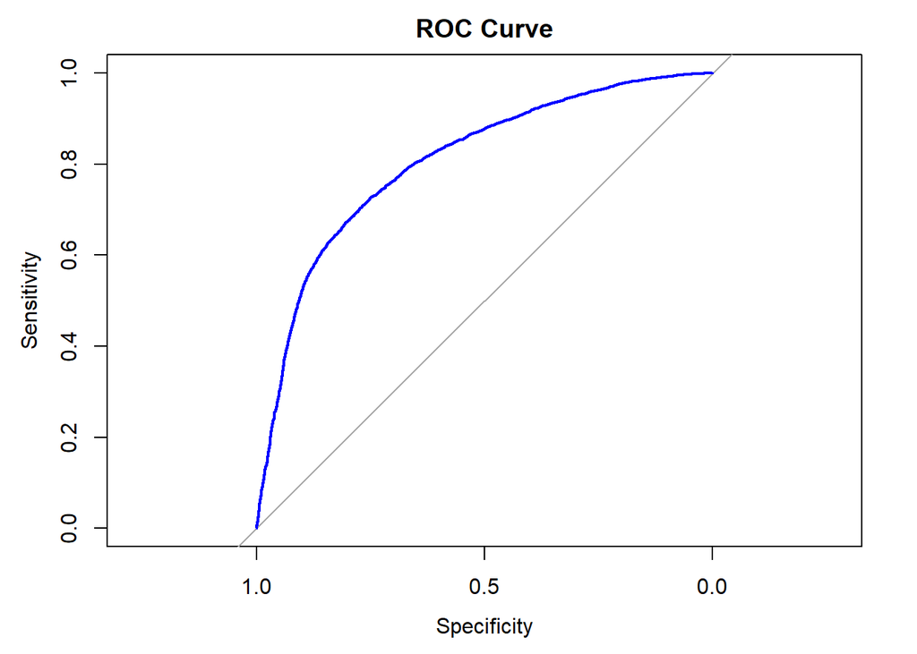

```r
# Get predicted probabilities
predictions <- predict(rf_model, newdata = test_data, type = "prob")
predicted_probs <- predictions[, "Yes"]
actual_labels <- test_data$cardio

# Manually compute the area under ROC curve
roc_curve_rf <- roc(as.numeric(actual_labels), predicted_probs)
# ROC curve
plot(roc_curve_rf, main = "ROC Curve", col = "blue", lwd = 2)
```

```r
rf_auc <- auc(roc_curve_rf)

# Save image
png("images/rf_roc_curve.png", width = 800, height = 600)
plot(roc_curve_rf, main = "ROC Curve", col = "blue", lwd = 2)
dev.off()
```

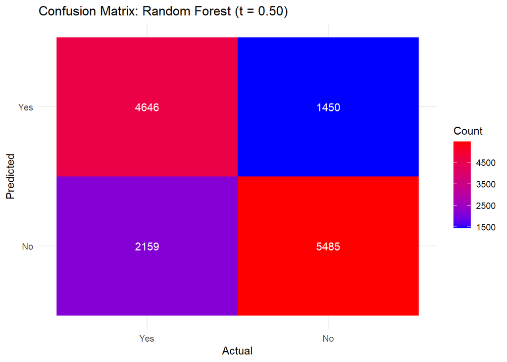

```r
## Confusion Matrix for Random Forest
predicted_class <- ifelse(predicted_probs >= 0.5, "Yes", "No")
levels(actual_labels) <- c("No", "Yes")
cm <- confusionMatrix(as.factor(predicted_class), as.factor(actual_labels))

# Convert the confusion matrix into a table
cm_table <- as.data.frame(cm$table)
cm_table$Reference <- factor(cm_table$Reference, levels = rev(levels(as.factor(actual_labels))))
colnames(cm_table) <- c("Prediction", "Reference", "Count")

# Plot the confusion matrix
rf_confusion_matrix <- ggplot(data = cm_table, aes(x = Reference, y = Prediction, fill = Count)) +
  geom_tile() +
  geom_text(aes(label = Count), color = "white") +
  scale_fill_gradient(low = "blue", high = "red") +
  theme_minimal() +
  labs(title = "Confusion Matrix: Random Forest (t = 0.50)", x = "Actual", y = "Predicted")
ggsave("images/rf_confusion_matrix_50.png", rf_confusion_matrix, width = 8, height = 8)
rf_confusion_matrix
```

```r
## Performance Metrics Calculation
TN <- cm$table[1,1]
FP <- cm$table[2,1]
FN <- cm$table[1,2]
TP <- cm$table[2,2]

# Calculate metrics
accuracy <- (TP + TN) / (TP + TN + FP + FN)
precision <- TP / (TP + FP)
recall <- TP / (TP + FN)  # Sensitivity
specificity <- TN / (TN + FP)
f1_score <- 2 * ((precision * recall) / (precision + recall))
fpr <- FP / (FP + TN)
fnr <- FN / (FN + TP)

# Create a dataframe for visualization
metrics_df <- data.frame(
  Metric = c("Accuracy", "Precision", "Recall (Sensitivity)", "Specificity", "F1-Score", "FPR", "FNR"),
  Value = c(accuracy, precision, recall, specificity, f1_score, fpr, fnr)
)

# Print computed metrics
print(metrics_df)
```

```
##                 Metric     Value
## 1             Accuracy 0.7373362
## 2            Precision 0.7621391
## 3 Recall (Sensitivity) 0.6827333
## 4          Specificity 0.7909156
## 5             F1-Score 0.7202542
## 6                  FPR 0.2090844
## 7                  FNR 0.3172667
```

As we could imagine, this enhanced version of classification trees gets a better performance in the classification task. However, we must take into account the high computational complexity of this new model compared with the previous ones.

If we observe the confusion matrix above, we easily realize that the model tends to underpredict the disease. Given the healthcare context in which we are, a lower threshold for the matrix should also be taken into account.

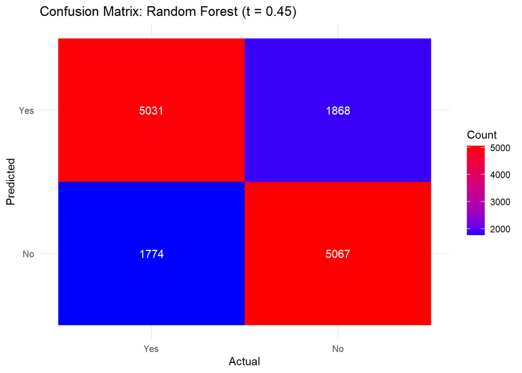

```r
## Confusion Matrix for Random Forest
predicted_class <- ifelse(predicted_probs >= 0.45, "Yes", "No")
cm <- confusionMatrix(as.factor(predicted_class), as.factor(actual_labels))

# Convert the confusion matrix into a table
cm_table <- as.data.frame(cm$table)
cm_table$Reference <- factor(cm_table$Reference, levels = rev(levels(as.factor(actual_labels))))
colnames(cm_table) <- c("Prediction", "Reference", "Count")

# Plot the confusion matrix
rf_confusion_matrix <- ggplot(data = cm_table, aes(x = Reference, y = Prediction, fill = Count)) +
  geom_tile() +
  geom_text(aes(label = Count), color = "white") +
  scale_fill_gradient(low = "blue", high = "red") +
  theme_minimal() +
  labs(title = "Confusion Matrix: Random Forest (t = 0.45)", x = "Actual", y = "Predicted")
ggsave("images/rf_confusion_matrix_45.png", rf_confusion_matrix, width = 8, height = 8)
rf_confusion_matrix
```

```r
## Performance Metrics Calculation
TN <- cm$table[1,1]
FP <- cm$table[2,1]
FN <- cm$table[1,2]
TP <- cm$table[2,2]

# Calculate metrics
accuracy <- (TP + TN) / (TP + TN + FP + FN)
precision <- TP / (TP + FP)
recall <- TP / (TP + FN)  # Sensitivity
specificity <- TN / (TN + FP)
f1_score <- 2 * ((precision * recall) / (precision + recall))
fpr <- FP / (FP + TN)
fnr <- FN / (FN + TP)

# Create a dataframe for visualization
rf_metrics_df <- data.frame(
  Metric = c("Accuracy", "Precision", "Recall (Sensitivity)", "Specificity", "F1-Score", "FPR", "FNR"),
  Value = c(accuracy, precision, recall, specificity, f1_score, fpr, fnr)
)

# Print computed metrics
print(rf_metrics_df)
```

```
##                 Metric     Value
## 1             Accuracy 0.7349345
## 2            Precision 0.7292361
## 3 Recall (Sensitivity) 0.7393093
## 4          Specificity 0.7306417
## 5             F1-Score 0.7342382
## 6                  FPR 0.2693583
## 7                  FNR 0.2606907
```

## Logistic Regression

### Basic Model

We fit some logistic regression models. These models are mainly used when the target variable is dichotomous, as in this case, where only two classes can be predicted. They to map the output of the model into a meaningful range for probabilities([0, 1]).

Let’s start building a general model, without interaction between variables. Again, a 5-fold cross-validation will be applied.

```r
ctrl <- trainControl(method = "cv", number = 5, classProbs = TRUE, summaryFunction = twoClassSummary)
levels(cardio$cardio) <- c("No", "Yes")
levels(train_data$cardio) <- c("No", "Yes")
levels(test_data$cardio) <- c("No", "Yes")


# Cross-validation
log_model <- train(
  cardio ~ .,                    # Formula
  data = train_data,             # Dataset
  method = "glm",                # Correct method for logistic regression
  family = binomial(link = "logit"),  # Logistic regression
  trControl = ctrl,              # Cross-validation settings
  metric = "ROC"            # Appropriate metric for classification
)

# Print the model
print(log_model)
```

```
## Generalized Linear Model
##
## 54959 samples
##    11 predictor
##     2 classes: 'No', 'Yes'
##
## No pre-processing
## Resampling: Cross-Validated (5 fold)
## Summary of sample sizes: 43967, 43968, 43968, 43966, 43967
## Resampling results:
##
##   ROC        Sens       Spec
##   0.7902634  0.7872266  0.6643115
```

At first sight, the results obtained are similar to the ones from the previous model.

Let’s plot the decision boundary with respect `ap_hi` and `ap_lo` to better see the relation between both variables:

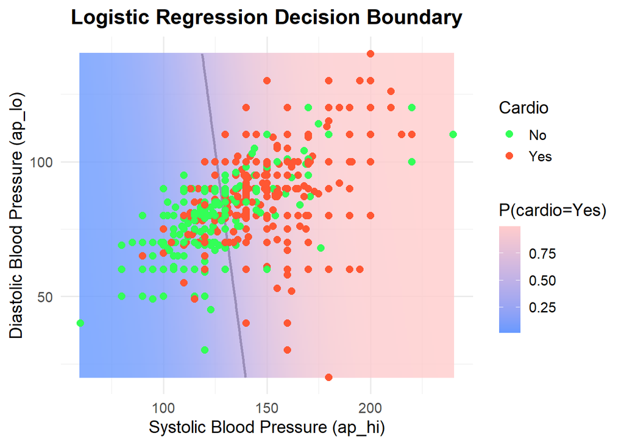

```r
grid <- expand.grid(
  ap_hi = seq(min(test_data$ap_hi), max(test_data$ap_hi), length.out = 200),
  ap_lo = seq(min(test_data$ap_lo), max(test_data$ap_lo), length.out = 200)
)

# For other predictors, calculate medians for numerical variables and most frequent levels for factors
other_predictors <- test_data %>%
  select(-c(ap_hi, ap_lo, cardio)) %>%
  summarise(across(where(is.numeric), median), across(where(is.factor), ~ names(sort(table(.), decreasing = TRUE)[1])))

# Repeat median/frequent level values for all rows of the grid
grid <- cbind(grid, other_predictors[rep(1, nrow(grid)), ])

# Convert factor levels in the grid to match the cardio dataset's levels
grid <- grid %>%
  mutate(across(where(is.factor), ~ factor(., levels = levels(cardio[[deparse(substitute(.))]]))))

# Predict probabilities for the grid
probabilities <- predict(log_model, newdata = grid, type = "prob")
grid$predicted_probs <- probabilities[, 2]  # Extract probabilities for the positive class

# Plot decision boundary
decision_boundary <- ggplot() +
  # Decision boundary contour
  geom_contour(data = grid, aes(x = ap_hi, y = ap_lo, z = predicted_probs), breaks = 0.5, color = "black", linetype = "solid", linewidth = 1) +

  # Filled contour plot
  geom_tile(data = grid, aes(x = ap_hi, y = ap_lo, fill = predicted_probs), alpha = 0.8) +
  scale_fill_gradient(low = "#6699FF", high = "#FFCCCC", name = "P(cardio=Yes)") +

  # Original data points
  geom_point(data = test_data, aes(x = ap_hi, y = ap_lo, color = as.factor(cardio)), size = 2.5) +
  scale_color_manual(values = c("No" = "#33FF57", "Yes" = "#FF5733"), name = "Cardio") +

  # Titles and themes
  labs(
    title = "Logistic Regression Decision Boundary",
    x = "Systolic Blood Pressure (ap_hi)", y = "Diastolic Blood Pressure (ap_lo)"
  ) +
  theme_minimal(base_size = 14) +
  theme(
    plot.title = element_text(hjust = 0.5, face = "bold"),
    legend.position = "right"
  )

# Save the plot
ggsave("images/decision_boundary_cardio.png", decision_boundary, width = 8, height = 8)

# Display the plot
decision_boundary
```

### Performance

Let’s compute some performance metrics:

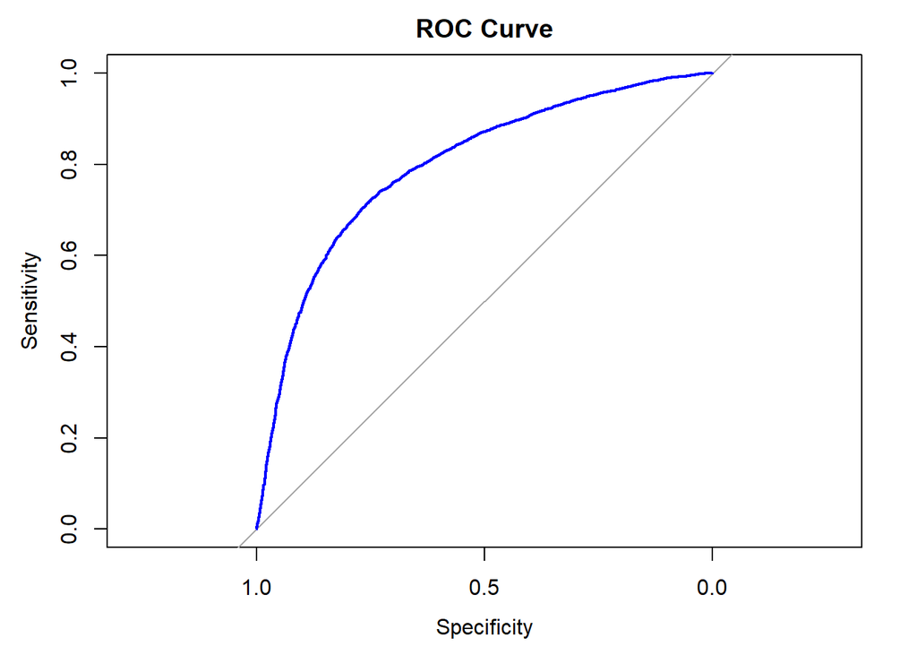

```r
# Get predicted probabilities
predictions <- predict(log_model, newdata = test_data, type = "prob")
predicted_probs <- predictions[, "Yes"]
actual_labels <- test_data$cardio

# Manually compute the area under ROC curve
roc_curve_lr <- roc(actual_labels, predicted_probs)
# ROC curve
plot(roc_curve_lr, main = "ROC Curve", col = "blue", lwd = 2)
```

```r
lr_auc <- auc(roc_curve_lr)

# Save image
png("images/lr_roc_curve.png", width = 800, height = 600)
plot(roc_curve_lr, main = "ROC Curve", col = "blue", lwd = 2)
dev.off()
```

```r
## Confusion Matrix for Logistic Regression
predicted_class <- ifelse(predicted_probs >= 0.5, "Yes", "No")
cm <- confusionMatrix(as.factor(predicted_class), as.factor(actual_labels))

# Convert the confusion matrix into a table
cm_table <- as.data.frame(cm$table)
cm_table$Reference <- factor(cm_table$Reference, levels = rev(levels(as.factor(actual_labels))))
colnames(cm_table) <- c("Prediction", "Reference", "Count")
cm
```

```
## Confusion Matrix and Statistics
##
##           Reference
## Prediction   No  Yes
##        No  5516 2237
##        Yes 1419 4568
##
##                Accuracy : 0.7339
##                  95% CI : (0.7264, 0.7413)
##     No Information Rate : 0.5047
##     P-Value [Acc > NIR] : < 2.2e-16
##
##                   Kappa : 0.4672
##
##  Mcnemar's Test P-Value : < 2.2e-16
##
##             Sensitivity : 0.7954
##             Specificity : 0.6713
##          Pos Pred Value : 0.7115
##          Neg Pred Value : 0.7630
##              Prevalence : 0.5047
##          Detection Rate : 0.4015
##    Detection Prevalence : 0.5643
##       Balanced Accuracy : 0.7333
##
##        'Positive' Class : No
##
```

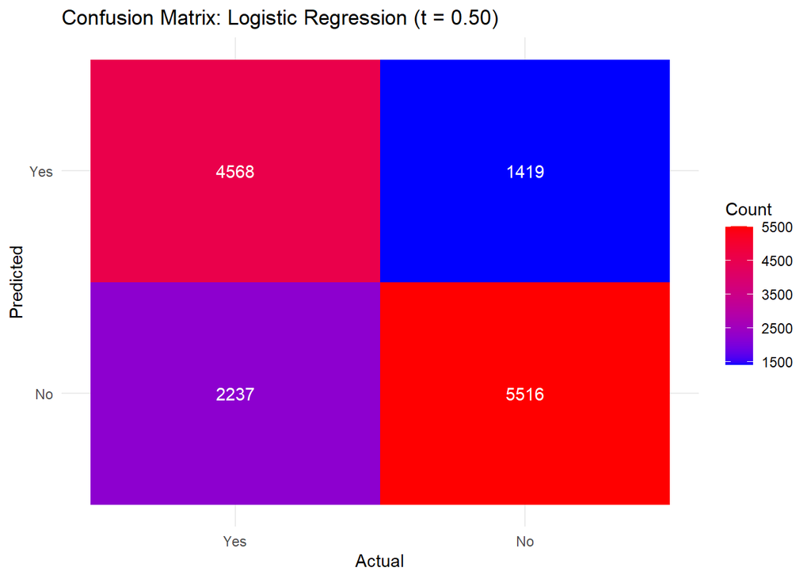

```r
# Plot the confusion matrix
lr_confusion_matrix <- ggplot(data = cm_table, aes(x = Reference, y = Prediction, fill = Count)) +
  geom_tile() +
  geom_text(aes(label = Count), color = "white") +
  scale_fill_gradient(low = "blue", high = "red") +
  theme_minimal() +
  labs(title = "Confusion Matrix: Logistic Regression (t = 0.50)", x = "Actual", y = "Predicted")
ggsave("images/lr_confusion_matrix_50.png", lr_confusion_matrix, width = 8, height = 8)
lr_confusion_matrix
```

```r
## Performance Metrics Calculation
TN <- cm$table[1,1]
FP <- cm$table[2,1]
FN <- cm$table[1,2]
TP <- cm$table[2,2]

# Calculate metrics
accuracy <- (TP + TN) / (TP + TN + FP + FN)
precision <- TP / (TP + FP)
recall <- TP / (TP + FN)  # Sensitivity
specificity <- TN / (TN + FP)
f1_score <- 2 * ((precision * recall) / (precision + recall))
fpr <- FP / (FP + TN)
fnr <- FN / (FN + TP)

# Create a dataframe for visualization
metrics_df <- data.frame(
  Metric = c("Accuracy", "Precision", "Recall (Sensitivity)", "Specificity", "F1-Score", "FPR", "FNR"),
  Value = c(accuracy, precision, recall, specificity, f1_score, fpr, fnr)
)

# Print computed metrics
print(metrics_df)
```

```
##                 Metric     Value
## 1             Accuracy 0.7339156
## 2            Precision 0.7629865
## 3 Recall (Sensitivity) 0.6712711
## 4          Specificity 0.7953857
## 5             F1-Score 0.7141964
## 6                  FPR 0.2046143
## 7                  FNR 0.3287289
```

```r
ratio <- metrics_df$Value[7]/metrics_df$Value[6]
```

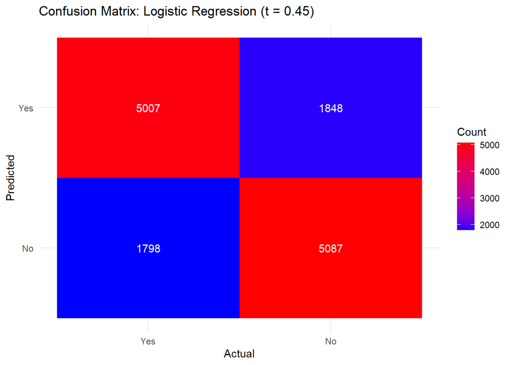

```r
## Confusion Matrix for Logistic Regression
predicted_class <- ifelse(predicted_probs >= 0.45, "Yes", "No")
cm <- confusionMatrix(as.factor(predicted_class), as.factor(actual_labels))

# Convert the confusion matrix into a table
cm_table <- as.data.frame(cm$table)
cm_table$Reference <- factor(cm_table$Reference, levels = rev(levels(as.factor(actual_labels))))
colnames(cm_table) <- c("Prediction", "Reference", "Count")

# Plot the confusion matrix
lr_confusion_matrix <- ggplot(data = cm_table, aes(x = Reference, y = Prediction, fill = Count)) +
  geom_tile() +
  geom_text(aes(label = Count), color = "white") +
  scale_fill_gradient(low = "blue", high = "red") +
  theme_minimal() +
  labs(title = "Confusion Matrix: Logistic Regression (t = 0.45)", x = "Actual", y = "Predicted")
ggsave("images/lr_confusion_matrix_45.png", lr_confusion_matrix, width = 8, height = 8)
lr_confusion_matrix
```

```r
## Performance Metrics Calculation
TN <- cm$table[1,1]
FP <- cm$table[2,1]
FN <- cm$table[1,2]
TP <- cm$table[2,2]

# Calculate metrics
accuracy <- (TP + TN) / (TP + TN + FP + FN)
precision <- TP / (TP + FP)
recall <- TP / (TP + FN)  # Sensitivity
specificity <- TN / (TN + FP)
f1_score <- 2 * ((precision * recall) / (precision + recall))
fpr <- FP / (FP + TN)
fnr <- FN / (FN + TP)

# Create a dataframe for visualization
lr_metrics_df <- data.frame(
  Metric = c("Accuracy", "Precision", "Recall (Sensitivity)", "Specificity", "F1-Score", "FPR", "FNR"),
  Value = c(accuracy, precision, recall, specificity, f1_score, fpr, fnr)
)

# Print computed metrics
print(lr_metrics_df)
```

```
##                 Metric     Value
## 1             Accuracy 0.7346434
## 2            Precision 0.7304158
## 3 Recall (Sensitivity) 0.7357825
## 4          Specificity 0.7335256
## 5             F1-Score 0.7330893
## 6                  FPR 0.2664744
## 7                  FNR 0.2642175
```

Considering that in a medical context it is often preferred to overpredict than to underpredict values, this lower threshold is preferred: while the false positive rate is increased, we are overall able to correctly classify more patients.

Understanding the contribution of each feature to the model could also help us explain the model in more depth:

```r
# Feature Importance
summary(log_model)
```

```
##
## Call:
## NULL
##
## Coefficients:
##                                  Estimate Std. Error z value Pr(>|z|)
## (Intercept)                    -1.075e+01  2.661e-01 -40.418  < 2e-16 ***
## age                             5.051e-02  1.514e-03  33.365  < 2e-16 ***
## genderM                        -4.618e-03  2.454e-02  -0.188  0.85070
## height                         -3.791e-03  1.434e-03  -2.644  0.00819 **
## weight                          1.070e-02  7.706e-04  13.889  < 2e-16 ***
## ap_hi                           5.662e-02  1.030e-03  54.941  < 2e-16 ***
## ap_lo                           9.884e-03  1.606e-03   6.154 7.53e-10 ***
## `cholesterolabove normal`       3.916e-01  3.053e-02  12.826  < 2e-16 ***
## `cholesterolwell above normal`  1.059e+00  3.957e-02  26.760  < 2e-16 ***
## `glucabove normal`              3.585e-02  4.039e-02   0.888  0.37479
## `glucwell above normal`        -3.263e-01  4.393e-02  -7.429 1.10e-13 ***
## smokeYes                       -1.498e-01  3.875e-02  -3.867  0.00011 ***
## alcoYes                        -2.175e-01  4.706e-02  -4.622 3.80e-06 ***
## activeYes                      -2.233e-01  2.441e-02  -9.147  < 2e-16 ***
## ---
## Signif. codes:  0 '***' 0.001 '**' 0.01 '*' 0.05 '.' 0.1 ' ' 1
##
## (Dispersion parameter for binomial family taken to be 1)
##
##     Null deviance: 76183  on 54958  degrees of freedom
## Residual deviance: 61705  on 54945  degrees of freedom
## AIC: 61733
##
## Number of Fisher Scoring iterations: 4
```

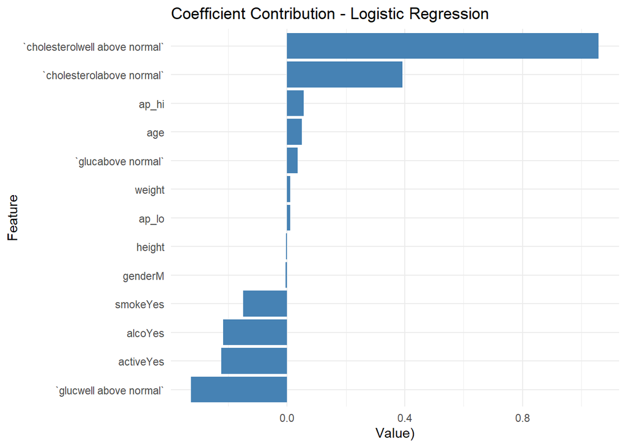

```r
importance_lr <- as.data.frame(summary(log_model)$coefficients)
importance_lr$Feature <- rownames(importance_lr)

# Remove intercept for better visualization
importance_lr <- importance_lr[importance_lr$Feature != "(Intercept)", ]

# Rename columns for clarity
colnames(importance_lr) <- c("Estimate", "StdError", "ZValue", "PValue", "Feature")

# Plot feature importance
feature_importance <- ggplot(importance_lr, aes(x=reorder(Feature, Estimate), y=Estimate)) +
  geom_bar(stat='identity', fill='steelblue') +
  coord_flip() +
  labs(title="Coefficient Contribution - Logistic Regression",
       x="Feature", y="Value)") +
  theme_minimal()
ggsave("images/feature_importance.png", feature_importance, width = 8, height = 8)
feature_importance
```

It is important to note that the plot compares categorical and numerical values. Scales are completely different (an increment of one unit in `cholesterol`, for example, is much more significant than the same increment in `ap_hi`). However, we can distinguish in an easy way which variables contribute positively or negatively to the prediction.

### Interaction between variables

#### Smoke & Alcohol Model

What if we introduce interaction between some of the variables? As we saw before, some pairs of features are highly correlated, e.g., `smoke` and `alco` or `gluc` and `cholesterol`. A reasonable approach could be building some models based on them.

```r
smoke_check = glm(cardio ~ smoke + alco, data = train_data, family = binomial(link = "logit") )
summary(smoke_check)
```

```
##
## Call:
## glm(formula = cardio ~ smoke + alco, family = binomial(link = "logit"),
##     data = train_data)
##
## Coefficients:
##              Estimate Std. Error z value Pr(>|z|)
## (Intercept) -0.010221   0.009017  -1.134 0.256996
## smokeYes    -0.114786   0.031944  -3.593 0.000326 ***
## alcoYes     -0.022633   0.040270  -0.562 0.574098
## ---
## Signif. codes:  0 '***' 0.001 '**' 0.01 '*' 0.05 '.' 0.1 ' ' 1
##
## (Dispersion parameter for binomial family taken to be 1)
##
##     Null deviance: 76183  on 54958  degrees of freedom
## Residual deviance: 76166  on 54956  degrees of freedom
## AIC: 76172
##
## Number of Fisher Scoring iterations: 3
```

Even if taken as the single predictor, they still counterintuitively contribute negatively to `cardio`. However the significance is lower than the one in the complete model.

In the data exploration part, we saw that there were, numerically, minimal differences between groups with regard to these variables. Furthermore both of these variables are *subjective*, meaning that the answer was at the respondent’s discretion. This means one could straight up lie, or even, having quit recently, answer *no* even though the effects of alcohol consumption or smoking were already present. That is a fact to be taken into consideration.

#### Glucose & Cholesterol Model

Let’s try with the second pair of variables.

```r
gluc_check = glm(cardio ~ gluc + cholesterol, data = train_data, family = binomial(link = "logit"))
summary(gluc_check)
```

```
##
## Call:
## glm(formula = cardio ~ gluc + cholesterol, family = binomial(link = "logit"),
##     data = train_data)
##
## Coefficients:
##                              Estimate Std. Error z value Pr(>|z|)
## (Intercept)                  -0.26130    0.01013 -25.785  < 2e-16 ***
## glucabove normal              0.20810    0.03519   5.914 3.33e-09 ***
## glucwell above normal        -0.23806    0.04003  -5.947 2.73e-09 ***
## cholesterolabove normal       0.61500    0.02664  23.082  < 2e-16 ***
## cholesterolwell above normal  1.49684    0.03563  42.009  < 2e-16 ***
## ---
## Signif. codes:  0 '***' 0.001 '**' 0.01 '*' 0.05 '.' 0.1 ' ' 1
##
## (Dispersion parameter for binomial family taken to be 1)
##
##     Null deviance: 76183  on 54958  degrees of freedom
## Residual deviance: 73377  on 54954  degrees of freedom
## AIC: 73387
##
## Number of Fisher Scoring iterations: 4
```

```r
interaction_gluc_cardio = glm(cardio ~ gluc*cholesterol, data = train_data, family = binomial(link = "logit"))
summary(interaction_gluc_cardio)
```

```
##
## Call:
## glm(formula = cardio ~ gluc * cholesterol, family = binomial(link = "logit"),
##     data = train_data)
##
## Coefficients:
##                                                    Estimate Std. Error z value
## (Intercept)                                        -0.28038    0.01033 -27.144
## glucabove normal                                    0.40533    0.04862   8.337
## glucwell above normal                               0.12701    0.05908   2.150
## cholesterolabove normal                             0.67619    0.02995  22.577
## cholesterolwell above normal                        1.75648    0.04656  37.724
## glucabove normal:cholesterolabove normal           -0.41501    0.07312  -5.675
## glucwell above normal:cholesterolabove normal      -0.05393    0.13710  -0.393
## glucabove normal:cholesterolwell above normal      -0.44697    0.14394  -3.105
## glucwell above normal:cholesterolwell above normal -0.82866    0.08520  -9.726
##                                                    Pr(>|z|)
## (Intercept)                                         < 2e-16 ***
## glucabove normal                                    < 2e-16 ***
## glucwell above normal                                0.0316 *
## cholesterolabove normal                             < 2e-16 ***
## cholesterolwell above normal                        < 2e-16 ***
## glucabove normal:cholesterolabove normal           1.38e-08 ***
## glucwell above normal:cholesterolabove normal        0.6940
## glucabove normal:cholesterolwell above normal        0.0019 **
## glucwell above normal:cholesterolwell above normal  < 2e-16 ***
## ---
## Signif. codes:  0 '***' 0.001 '**' 0.01 '*' 0.05 '.' 0.1 ' ' 1
##
## (Dispersion parameter for binomial family taken to be 1)
##
##     Null deviance: 76183  on 54958  degrees of freedom
## Residual deviance: 73242  on 54950  degrees of freedom
## AIC: 73260
##
## Number of Fisher Scoring iterations: 4
```

The weird effect is present just on levels of `gluc` *above normal* when they interact with high cholesterol. Taken individually, when they are significant, they contribute positively to the insurgence of heart diseases, as expected.

#### Pulse Pressure Model

It would be interesting to work with *pulse pressure* too. It is an important mortality predictor and, according to some researchers, it appears to be a stronger independent predictor of mortality than other parameters such as systolic or diastolic pressures by themselves (Malone and Reddan 2010).

Pulse pressure is a function consisting on the difference of systolic and diastolic pressures: $ap\_pu = ap\_hi - ap\_lo$.

```r
cardio_cl$ap_pu = cardio$ap_hi - cardio$ap_lo
log_model_ap_pu <- train(
  cardio ~ . -ap_hi-ap_lo,       # Formula
  data = train_data,             # Dataset
  method = "glm",                # Correct method for logistic regression
  family = binomial(link = "logit"),  # Logistic regression
  trControl = ctrl,              # Cross-validation settings
  metric = "ROC"            # Appropriate metric for classification
)

print(log_model_ap_pu)
```

```
## Generalized Linear Model
##
## 54959 samples
##    11 predictor
##     2 classes: 'No', 'Yes'
##
## No pre-processing
## Resampling: Cross-Validated (5 fold)
## Summary of sample sizes: 43967, 43968, 43967, 43968, 43966
## Resampling results:
##
##   ROC        Sens       Spec
##   0.6965453  0.6825318  0.6006693
```

```r
summary(log_model_ap_pu)
```

```
##
## Call:
## NULL
##
## Coefficients:
##                                  Estimate Std. Error z value Pr(>|z|)
## (Intercept)                    -3.6215053  0.2282312 -15.868  < 2e-16 ***
## age                             0.0655732  0.0014009  46.807  < 2e-16 ***
## genderM                         0.1091906  0.0229688   4.754  2.0e-06 ***
## height                         -0.0108534  0.0013420  -8.087  6.1e-16 ***
## weight                          0.0247341  0.0007091  34.881  < 2e-16 ***
## `cholesterolabove normal`       0.5461120  0.0277263  19.697  < 2e-16 ***
## `cholesterolwell above normal`  1.2719865  0.0371354  34.253  < 2e-16 ***
## `glucabove normal`              0.0901780  0.0367447   2.454 0.014121 *
## `glucwell above normal`        -0.3507499  0.0412034  -8.513  < 2e-16 ***
## smokeYes                       -0.1152763  0.0357626  -3.223 0.001267 **
## alcoYes                        -0.1434307  0.0433020  -3.312 0.000925 ***
## activeYes                      -0.1916271  0.0227866  -8.410  < 2e-16 ***
## ---
## Signif. codes:  0 '***' 0.001 '**' 0.01 '*' 0.05 '.' 0.1 ' ' 1
##
## (Dispersion parameter for binomial family taken to be 1)
##
##     Null deviance: 76183  on 54958  degrees of freedom
## Residual deviance: 69472  on 54947  degrees of freedom
## AIC: 69496
##
## Number of Fisher Scoring iterations: 4
```

Nevertheless, results seem to be similar, if not worse, compared with previous models.

### Polynomial Regressions

#### Residuals

Let’s check the residual plots, using binned residuals:

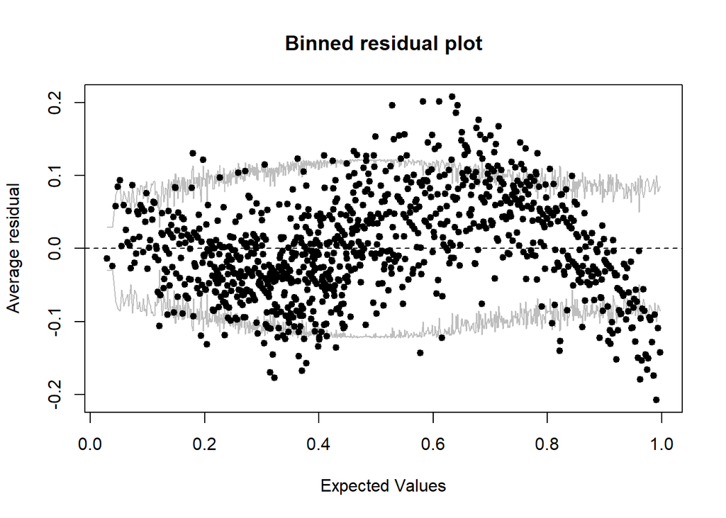

```r
fit <- glm(cardio ~ ., data = cardio, family = binomial(link = "logit"))
pred <- predict(fit, type = "response")
res <- residuals(fit, type = "response")

cardio$cardio <- factor(cardio$cardio, levels = c("No", "Yes"), labels = c(0, 1))

binnedplot(pred,res, nclass = 1000)
```

Let’s see if a polynomial regression can improve the model’s fit.

```r
fit_poly3 <- glm(cardio ~ .+poly(ap_hi, 3), data = cardio, family = binomial(link = "logit"))

pred <- predict(fit_poly3, type = "response")
res <- residuals(fit_poly3, type = "response")
summary(fit_poly3)
```

```
##
## Call:
## glm(formula = cardio ~ . + poly(ap_hi, 3), family = binomial(link = "logit"),
##     data = cardio)
##
## Coefficients: (1 not defined because of singularities)
##                                Estimate Std. Error z value Pr(>|z|)
## (Intercept)                  -1.052e+01  2.399e-01 -43.875  < 2e-16 ***
## age                           5.139e-02  1.365e-03  37.653  < 2e-16 ***
## genderM                      -1.850e-02  2.208e-02  -0.838   0.4021
## height                       -2.502e-03  1.292e-03  -1.936   0.0529 .
## weight                        1.049e-02  6.922e-04  15.153  < 2e-16 ***
## ap_hi                         5.248e-02  8.972e-04  58.488  < 2e-16 ***
## ap_lo                         1.077e-02  1.453e-03   7.410 1.26e-13 ***
## cholesterolabove normal       3.639e-01  2.752e-02  13.224  < 2e-16 ***
## cholesterolwell above normal  1.084e+00  3.593e-02  30.180  < 2e-16 ***
## glucabove normal              1.379e-02  3.638e-02   0.379   0.7046
## glucwell above normal        -3.469e-01  3.981e-02  -8.714  < 2e-16 ***
## smokeYes                     -1.525e-01  3.507e-02  -4.349 1.37e-05 ***
## alcoYes                      -2.254e-01  4.272e-02  -5.276 1.32e-07 ***
## activeYes                    -2.315e-01  2.200e-02 -10.526  < 2e-16 ***
## poly(ap_hi, 3)1                      NA         NA      NA       NA
## poly(ap_hi, 3)2              -2.875e+01  2.971e+00  -9.678  < 2e-16 ***
## poly(ap_hi, 3)3              -6.555e+01  2.939e+00 -22.306  < 2e-16 ***
## ---
## Signif. codes:  0 '***' 0.001 '**' 0.01 '*' 0.05 '.' 0.1 ' ' 1
##
## (Dispersion parameter for binomial family taken to be 1)
##
##     Null deviance: 95229  on 68698  degrees of freedom
## Residual deviance: 76458  on 68683  degrees of freedom
## AIC: 76490
##
## Number of Fisher Scoring iterations: 4
```

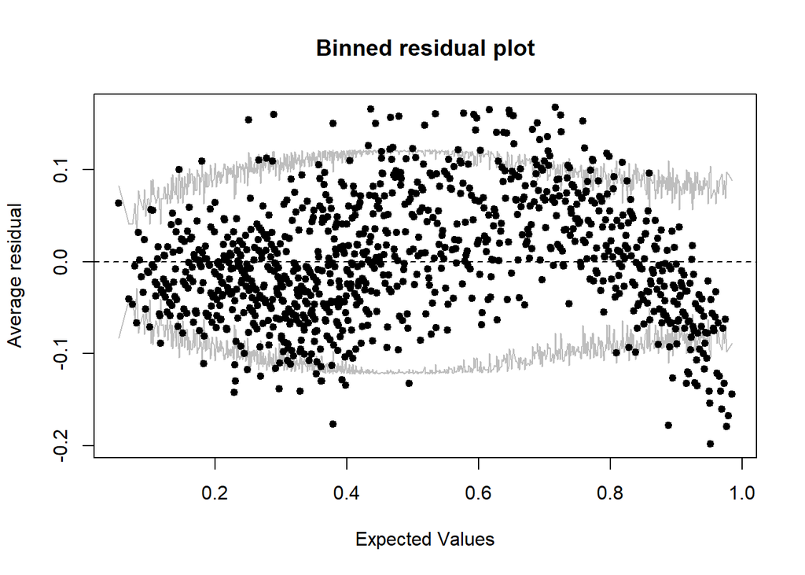

```r
binnedplot(pred,res, nclass = 1000)
```

```r
fit_poly4 <- glm(cardio ~ .+poly(ap_hi, 4), data = cardio, family = binomial(link = "logit"))

pred <- predict(fit_poly4, type = "response")
res <- residuals(fit_poly4, type = "response")
summary(fit_poly4)
```

```
##
## Call:
## glm(formula = cardio ~ . + poly(ap_hi, 4), family = binomial(link = "logit"),
##     data = cardio)
##
## Coefficients: (1 not defined because of singularities)
##                                Estimate Std. Error z value Pr(>|z|)
## (Intercept)                  -1.031e+01  2.393e-01 -43.072  < 2e-16 ***
## age                           5.119e-02  1.369e-03  37.395  < 2e-16 ***
## genderM                      -2.003e-02  2.216e-02  -0.904    0.366
## height                       -2.171e-03  1.296e-03  -1.675    0.094 .
## weight                        1.025e-02  6.932e-04  14.788  < 2e-16 ***
## ap_hi                         5.110e-02  8.668e-04  58.950  < 2e-16 ***
## ap_lo                         9.847e-03  1.447e-03   6.807 9.98e-12 ***
## cholesterolabove normal       3.567e-01  2.758e-02  12.933  < 2e-16 ***
## cholesterolwell above normal  1.071e+00  3.606e-02  29.700  < 2e-16 ***
## glucabove normal              1.304e-02  3.641e-02   0.358    0.720
## glucwell above normal        -3.478e-01  3.993e-02  -8.710  < 2e-16 ***
## smokeYes                     -1.563e-01  3.513e-02  -4.448 8.65e-06 ***
## alcoYes                      -2.288e-01  4.277e-02  -5.349 8.83e-08 ***
## activeYes                    -2.307e-01  2.206e-02 -10.458  < 2e-16 ***
## poly(ap_hi, 4)1                      NA         NA      NA       NA
## poly(ap_hi, 4)2              -3.275e+01  2.688e+00 -12.184  < 2e-16 ***
## poly(ap_hi, 4)3              -6.217e+01  2.615e+00 -23.773  < 2e-16 ***
## poly(ap_hi, 4)4               4.097e+01  2.726e+00  15.028  < 2e-16 ***
## ---
## Signif. codes:  0 '***' 0.001 '**' 0.01 '*' 0.05 '.' 0.1 ' ' 1
##
## (Dispersion parameter for binomial family taken to be 1)
##
##     Null deviance: 95229  on 68698  degrees of freedom
## Residual deviance: 76220  on 68682  degrees of freedom
## AIC: 76254
##
## Number of Fisher Scoring iterations: 4
```

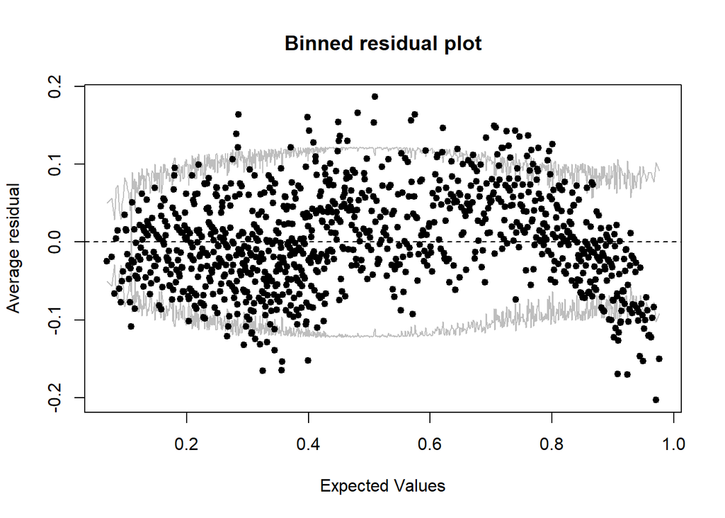

```r
binnedplot(pred,res, nclass = 1000)
```

Including a polynomial term for `ap_hi` in our model, the strongly non-linear pattern seen in the residuals of the “vanilla” model seems to become sparser, even though there is still some unexplained variance in the plot. All degrees of the polynomial for systolic blood pressure are significant, improving the model’s fit.

#### Polynomial of degree 3

```r
# Cross-validation
poly3 <- train(
  cardio ~ . + poly(ap_hi, 3),   # Formula
  data = train_data,             # Dataset
  method = "glm",                # Correct method for logistic regression
  family = binomial(link = "logit"),  # Logistic regression
  trControl = ctrl,              # Cross-validation settings
  metric = "ROC"            # Appropriate metric for classification
)

# General results
poly3$results
```

|  | parameter | ROC | Sens | Spec | ROCSD | SensSD | SpecSD |
| --- | --- | --- | --- | --- | --- | --- | --- |
| 1 | none | 0.7915999 | 0.7935989 | 0.6584626 | 0.003614617 | 0.00389401 | 0.008651405 |

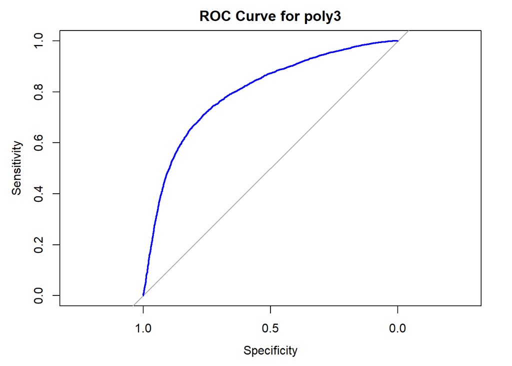

```r
# Get predicted probabilities
predictions <- predict(poly3, newdata = test_data, type = "prob")
predicted_class <- ifelse(predicted_probs >= 0.45, "Yes", "No")
predicted_probs <- predictions[, "Yes"]
actual_labels <- test_data$cardio

# Manually compute the area under ROC curve
roc_curve_poly3 <- roc(actual_labels, predicted_probs)
auc_poly3 <- auc(roc_curve_poly3)

# Create confusion matrix
cm <- confusionMatrix(
  factor(predicted_class),
  factor(actual_labels),
  positive = "Yes"
)

## Performance Metrics Calculation
TN <- cm$table[1,1]
FP <- cm$table[2,1]
FN <- cm$table[1,2]
TP <- cm$table[2,2]

# Calculate metrics
accuracy <- (TP + TN) / (TP + TN + FP + FN)
precision <- TP / (TP + FP)
recall <- TP / (TP + FN)  # Sensitivity
specificity <- TN / (TN + FP)
f1_score <- 2 * ((precision * recall) / (precision + recall))
fpr <- FP / (FP + TN)
fnr <- FN / (FN + TP)

# Create a dataframe for visualization
poly3_metrics_df <- data.frame(
  Metric = c("Accuracy", "Precision", "Recall (Sensitivity)", "Specificity", "F1-Score", "FPR", "FNR"),
  Value = c(accuracy, precision, recall, specificity, f1_score, fpr, fnr)
)

# ROC curve
plot(roc_curve_poly3, main = "ROC Curve for poly3", col = "blue", lwd = 2)
```

```r
roc_curve_poly3$auc
```

```
## Area under the curve: 0.7988
```

#### Polynomial of degree 4

```r
# Cross-validation
poly4 <- train(
  cardio ~ . + poly(ap_hi, 4),   # Formula
  data = train_data,             # Dataset
  method = "glm",                # Correct method for logistic regression
  family = binomial(link = "logit"),  # Logistic regression
  trControl = ctrl,              # Cross-validation settings
  metric = "ROC"            # Appropriate metric for classification
)

# General results
poly4$results
```

|  | parameter | ROC | Sens | Spec | ROCSD | SensSD | SpecSD |
| --- | --- | --- | --- | --- | --- | --- | --- |
| 1 | none | 0.7909927 | 0.7915466 | 0.6603389 | 0.003874732 | 0.00473492 | 0.004647464 |

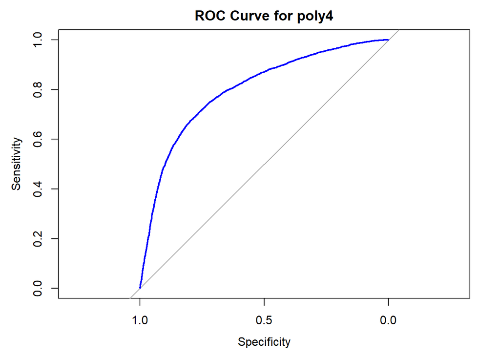

```r
# Get predicted probabilities
predictions <- predict(poly4, newdata = test_data, type = "prob")
predicted_class <- ifelse(predicted_probs >= 0.45, "Yes", "No")
predicted_probs <- predictions[, "Yes"]
actual_labels <- test_data$cardio

# Manually compute the area under ROC curve
roc_curve_poly4 <- roc(actual_labels, predicted_probs)
auc_poly4 <- auc(roc_curve_poly4)

# Create confusion matrix
cm <- confusionMatrix(
  factor(predicted_class),
  factor(actual_labels),
  positive = "Yes"
)

## Performance Metrics Calculation
TN <- cm$table[1,1]
FP <- cm$table[2,1]
FN <- cm$table[1,2]
TP <- cm$table[2,2]

# Calculate metrics
accuracy <- (TP + TN) / (TP + TN + FP + FN)
precision <- TP / (TP + FP)
recall <- TP / (TP + FN)  # Sensitivity
specificity <- TN / (TN + FP)
f1_score <- 2 * ((precision * recall) / (precision + recall))
fpr <- FP / (FP + TN)
fnr <- FN / (FN + TP)

# Create a dataframe for visualization
poly4_metrics_df <- data.frame(
  Metric = c("Accuracy", "Precision", "Recall (Sensitivity)", "Specificity", "F1-Score", "FPR", "FNR"),
  Value = c(accuracy, precision, recall, specificity, f1_score, fpr, fnr)
)
# ROC curve
plot(roc_curve_poly4, main = "ROC Curve for poly4", col = "blue", lwd = 2)
```

```r
roc_curve_poly4$auc
```

```
## Area under the curve: 0.7983
```

#### LASSO

It’s possible to see that by considering the polynomials of the systolic blood pressure, the residuals follow less of a pattern. Further factors (like higher polynomials and multiple interactions) were also considered but they did not contribute to improving the model.

We still get strange values for some coefficients (e.g. `gluc`).

We apply LASSO regression to see what coefficients are actually important.

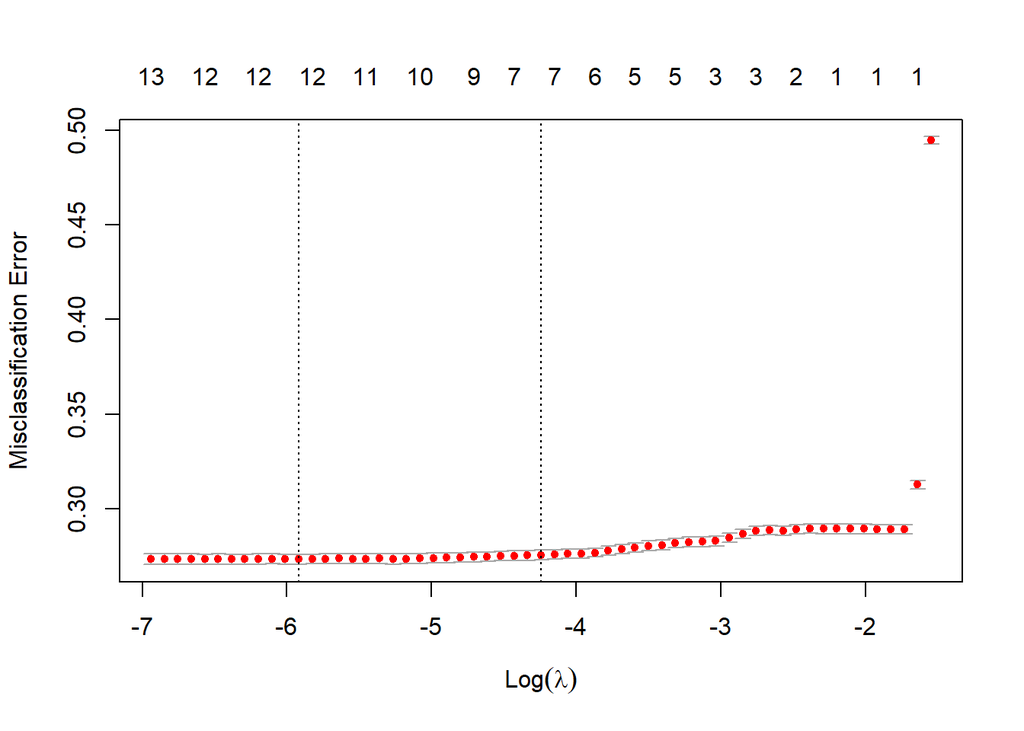

```r
set.seed(23)
# Model matrix creation
train_data_dummies <- model.matrix(cardio ~ ., data = train_data)[, -1]  # Exclude intercept column
test_data_dummies <- model.matrix(cardio ~ ., data = test_data)[, -1]    # Exclude intercept column

X_train <- scale(train_data_dummies)
Y_train <- as.numeric(train_data$cardio) - 1  # Assuming 'cardio' is a factor variable (0/1)
X_test <- scale(test_data_dummies)
Y_test <- as.numeric(test_data$cardio) - 1  # Assuming 'cardio' is a factor variable (0/1)

# Fit the model using cv.glmnet
cvfit <- cv.glmnet(X_train, Y_train, family = "binomial", type.measure = "class", alpha = 1)
plot(cvfit)
```

```r
print(cvfit)
```

```
##
## Call:  cv.glmnet(x = X_train, y = Y_train, type.measure = "class", family = "binomial",      alpha = 1)
##
## Measure: Misclassification Error
##
##       Lambda Index Measure       SE Nonzero
## min 0.002692    48  0.2733 0.002599      12
## 1se 0.014366    30  0.2756 0.002483       7
```

By using a $\lambda$ which produces a misclassification error within 1 standard error from the minimum’s, we obtain similar results, while also simplifying the model: those problematic coefficients from before are shrunk to 0, underlying their secondary importance in determining the presence of heart disease. This is indeed consistent with what we had supposed in our initial exploration of the data.

```r
# Get optimal lambda values
lambda_min <- cvfit$lambda.min
lambda_1se <- cvfit$lambda.1se
cat("Lambda.min:", lambda_min, "\n")
```

```
## Lambda.min: 0.00269194
```

```r
cat("Lambda.1se:", lambda_1se, "\n")
```

```
## Lambda.1se: 0.01436608
```

```r
# Coefficients
cat("Coefficients at lambda.min:\n")
```

```
## Coefficients at lambda.min:
```

```r
print(coef(cvfit, s = "lambda.min"))
```

```
## 14 x 1 sparse Matrix of class "dgCMatrix"
##                                        s1
## (Intercept)                   0.025520282
## age                           0.329720899
## genderM                       .
## height                       -0.017612366
## weight                        0.136613583
## ap_hi                         0.931180242
## ap_lo                         0.086564237
## cholesterolabove normal       0.120751118
## cholesterolwell above normal  0.305491938
## glucabove normal              0.001518038
## glucwell above normal        -0.055358065
## smokeYes                     -0.033647368
## alcoYes                      -0.036341978
## activeYes                    -0.074554245
```

```r
cat("Coefficients at lambda.1se:\n")
```

```
## Coefficients at lambda.1se:
```

```r
print(coef(cvfit, s = "lambda.1se"))
```

```
## 14 x 1 sparse Matrix of class "dgCMatrix"
##                                       s1
## (Intercept)                   0.01484379
## age                           0.28173101
## genderM                       .
## height                        .
## weight                        0.08340519
## ap_hi                         0.87972895
## ap_lo                         0.05471067
## cholesterolabove normal       0.05756960
## cholesterolwell above normal  0.21352077
## glucabove normal              .
## glucwell above normal         .
## smokeYes                      .
## alcoYes                       .
## activeYes                    -0.01609376
```

```r
# Predictions on test data
predictions <- predict(cvfit, newx = X_test, s = "lambda.min", type = "response")
predicted_classes <- ifelse(predictions > 0.5, 1, 0)
```

```r
# Training predictions (lambda.min)
train_predictions_min <- predict(cvfit, newx = X_train, s = "lambda.min", type = "response")
train_pred_classes_min <- ifelse(train_predictions_min > 0.5, 1, 0)
train_accuracy_min <- mean(train_pred_classes_min == Y_train)
train_roc_min <- roc(Y_train, as.vector(train_predictions_min))
train_conf_matrix_min <- table(Predicted = train_pred_classes_min, Actual = Y_train)

# Test predictions (lambda.min)
test_predictions_min <- predict(cvfit, newx = X_test, s = "lambda.min", type = "response")
test_pred_classes_min <- ifelse(test_predictions_min > 0.5, 1, 0)
test_accuracy_min <- mean(test_pred_classes_min == as.numeric(test_data$cardio) - 1)
test_roc_min <- roc(as.numeric(test_data$cardio) - 1, as.vector(test_predictions_min))
test_conf_matrix_min <- table(Predicted = test_pred_classes_min, Actual = as.numeric(test_data$cardio) - 1)

# Training predictions (lambda.1se)
train_predictions_1se <- predict(cvfit, newx = X_train, s = "lambda.1se", type = "response")
train_pred_classes_1se <- ifelse(train_predictions_1se > 0.5, 1, 0)
train_accuracy_1se <- mean(train_pred_classes_1se == Y_train)
train_roc_1se <- roc(Y_train, as.vector(train_predictions_1se))
train_conf_matrix_1se <- table(Predicted = train_pred_classes_1se, Actual = Y_train)


# Test predictions (lambda.1se)
test_predictions_1se <- predict(cvfit, newx = X_test, s = "lambda.1se", type = "response")
test_pred_classes_1se <- ifelse(test_predictions_1se > 0.5, 1, 0)
test_accuracy_1se <- mean(test_pred_classes_1se == as.numeric(test_data$cardio) - 1)
test_roc_1se <- roc(as.numeric(test_data$cardio) - 1, as.vector(test_predictions_1se))
test_conf_matrix_1se <- table(Predicted = test_pred_classes_1se, Actual = as.numeric(test_data$cardio) - 1)


# Calculate MSE for training and test sets
train_mse_min <- mean((train_predictions_min - Y_train)^2)
train_mse_1se <- mean((train_predictions_1se - Y_train)^2)
test_mse_min <- mean((test_predictions_min - (as.numeric(test_data$cardio) - 1))^2)
test_mse_1se <- mean((test_predictions_1se - (as.numeric(test_data$cardio) - 1))^2)


# Create a summary table
results <- data.frame(
  Metric = c(
    "Training Accuracy", "Training AUC", "Training MSE",
    "Test Accuracy", "Test AUC", "Test MSE"
  ),
  Lambda_Min = c(
    train_accuracy_min, auc(train_roc_min), train_mse_min,
    test_accuracy_min, auc(test_roc_min), test_mse_min
  ),
  Lambda_1SE = c(
    train_accuracy_1se, auc(train_roc_1se), train_mse_1se,
    test_accuracy_1se, auc(test_roc_1se), test_mse_1se
  )
)

print("Summary of Results:")
```

```
## [1] "Summary of Results:"
```

```r
results
```

| Metric | Lambda_Min | Lambda_1SE |
| --- | --- | --- |
| Training Accuracy | 0.7267963 | 0.7244309 |
| Training AUC | 0.7905121 | 0.7883330 |
| Training MSE | 0.1876226 | 0.1897980 |
| Test Accuracy | 0.7342067 | 0.7321689 |
| Test AUC | 0.7963870 | 0.7941950 |
| Test MSE | 0.1850086 | 0.1874729 |

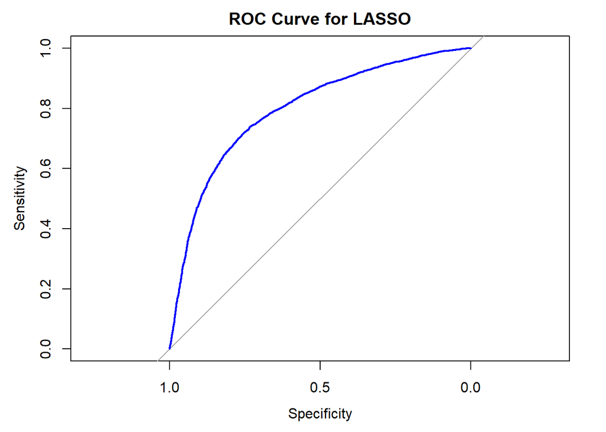

```r
fits1 <- glmnet(X_train, Y_train, family = "binomial", type.measure = "class", alpha = 1, lambda = lambda_1se)

# Get predicted probabilities
predicted_probs <- predict(fits1, newx = X_test, type = "response")
predicted_class <- ifelse(predicted_probs >= 0.5, "Yes", "No")
actual_labels <- as.factor(Y_test)
levels(actual_labels) <- c("No", "Yes")

# Create confusion matrix
cm <- confusionMatrix(
  factor(predicted_class),
  factor(actual_labels),
  positive = "Yes"
)

## Performance Metrics Calculation
TN <- cm$table[1,1]
FP <- cm$table[2,1]
FN <- cm$table[1,2]
TP <- cm$table[2,2]

# Calculate metrics
accuracy <- (TP + TN) / (TP + TN + FP + FN)
precision <- TP / (TP + FP)
recall <- TP / (TP + FN)  # Sensitivity
specificity <- TN / (TN + FP)
f1_score <- 2 * ((precision * recall) / (precision + recall))
fpr <- FP / (FP + TN)
fnr <- FN / (FN + TP)

# Create a dataframe for visualization
lasso_metrics_df <- data.frame(
  Metric = c("Accuracy", "Precision", "Recall (Sensitivity)", "Specificity", "F1-Score", "FPR", "FNR"),
  Value = c(accuracy, precision, recall, specificity, f1_score, fpr, fnr)
)

# Manually compute the area under ROC curve
roc_curve_lasso <- roc(actual_labels, as.numeric(predictions))
lasso_auc <- auc(roc_curve_lasso)

# ROC curve
plot(roc_curve_lasso, main = "ROC Curve for LASSO", col = "blue", lwd = 2)
```

```r
roc_curve_lasso$auc
```

```
## Area under the curve: 0.7964
```

### Splines

```r
set.seed(23)
fit <- glm(cardio ~ ns(age, df = 4) + ns(height, df = 4) + ns(weight, df = 4) + ns(ap_hi, df = 4) +
              ns(ap_lo, df = 4) + gender + cholesterol + gluc + smoke + alco + active,
            data = train_data, family = binomial(link = "logit"))

fit_step <- stepAIC(fit, direction = "both", trace = FALSE)

summary(fit_step)
```

```
##
## Call:
## glm(formula = cardio ~ ns(age, df = 4) + ns(weight, df = 4) +
##     ns(ap_hi, df = 4) + ns(ap_lo, df = 4) + gender + cholesterol +
##     gluc + smoke + alco + active, family = binomial(link = "logit"),
##     data = train_data)
##
## Coefficients:
##                              Estimate Std. Error z value Pr(>|z|)
## (Intercept)                  -4.58100    0.71560  -6.402 1.54e-10 ***
## ns(age, df = 4)1              2.24434    0.19279  11.641  < 2e-16 ***
## ns(age, df = 4)2              1.86112    0.13650  13.634  < 2e-16 ***
## ns(age, df = 4)3              5.12883    0.45337  11.313  < 2e-16 ***
## ns(age, df = 4)4              1.86958    0.07458  25.068  < 2e-16 ***
## ns(weight, df = 4)1           2.48037    0.45395   5.464 4.65e-08 ***
## ns(weight, df = 4)2           1.93801    0.27736   6.987 2.80e-12 ***
## ns(weight, df = 4)3           4.89964    0.93571   5.236 1.64e-07 ***
## ns(weight, df = 4)4           1.54248    0.46801   3.296 0.000981 ***
## ns(ap_hi, df = 4)1            1.05625    0.22114   4.777 1.78e-06 ***
## ns(ap_hi, df = 4)2            5.20708    0.17840  29.187  < 2e-16 ***
## ns(ap_hi, df = 4)3            1.77863    0.49366   3.603 0.000315 ***
## ns(ap_hi, df = 4)4           -0.81181    0.38502  -2.108 0.034988 *
## ns(ap_lo, df = 4)1           -1.37058    0.50872  -2.694 0.007056 **
## ns(ap_lo, df = 4)2            0.06568    0.32895   0.200 0.841736
## ns(ap_lo, df = 4)3           -3.22902    1.11779  -2.889 0.003868 **
## ns(ap_lo, df = 4)4           -1.11253    0.91050  -1.222 0.221750
## genderM                      -0.03274    0.02243  -1.459 0.144450
## cholesterolabove normal       0.36061    0.03087  11.680  < 2e-16 ***
## cholesterolwell above normal  1.03776    0.04002  25.929  < 2e-16 ***
## glucabove normal              0.02688    0.04069   0.661 0.508886
## glucwell above normal        -0.31351    0.04444  -7.054 1.74e-12 ***
## smokeYes                     -0.16176    0.03918  -4.128 3.65e-05 ***
## alcoYes                      -0.22726    0.04754  -4.780 1.75e-06 ***
## activeYes                    -0.23000    0.02465  -9.332  < 2e-16 ***
## ---
## Signif. codes:  0 '***' 0.001 '**' 0.01 '*' 0.05 '.' 0.1 ' ' 1
##
## (Dispersion parameter for binomial family taken to be 1)
##
##     Null deviance: 76183  on 54958  degrees of freedom
## Residual deviance: 60864  on 54934  degrees of freedom
## AIC: 60914
##
## Number of Fisher Scoring iterations: 4
```

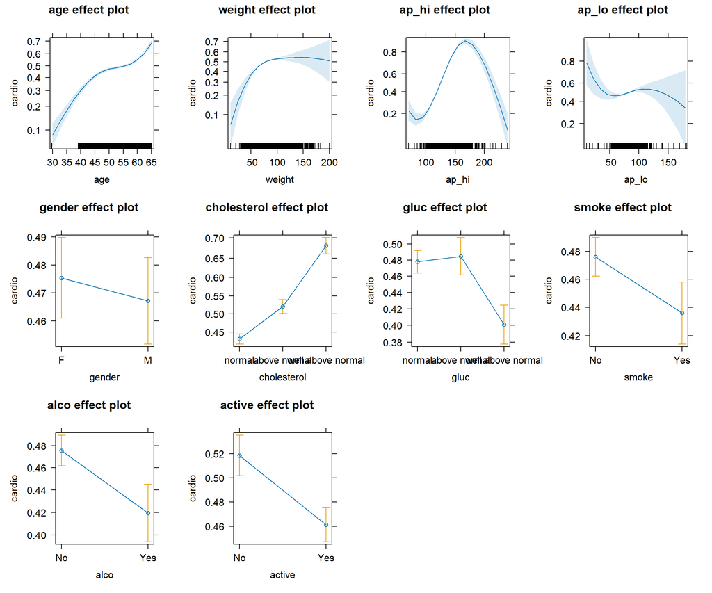

```r
pred <- predict(fit_step, type = "response")
res <- residuals(fit_step, type = "response")
plot(allEffects(fit_step))
```

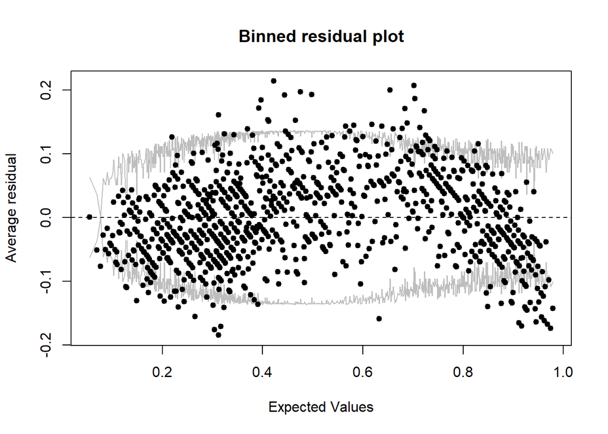

```r
arm::binnedplot(pred, res, nclass = 1000)
```

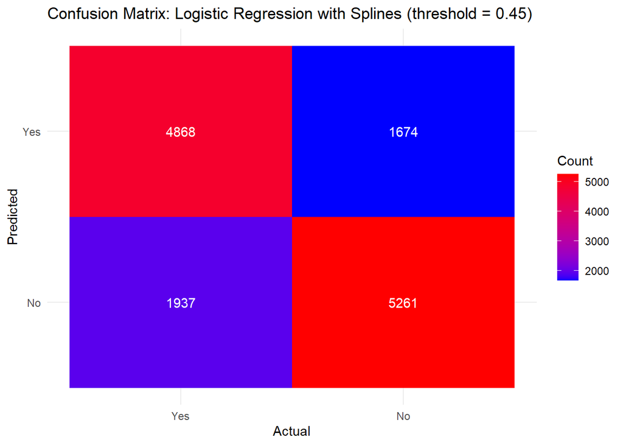

```r
predicted_probs <- predict(fit_step, newdata = test_data, type = "response")
predicted_class <- ifelse(predicted_probs >= 0.45, "Yes", "No")
actual_labels <- test_data$cardio
cm <- confusionMatrix(as.factor(predicted_class), as.factor(actual_labels))
cm_table <- as.data.frame(cm$table)
cm_table$Reference <- factor(cm_table$Reference, levels = rev(levels(as.factor(actual_labels))))
colnames(cm_table) <- c("Prediction", "Reference", "Count")

spline_confusion_matrix <- ggplot(data = cm_table, aes(x = Reference, y = Prediction, fill = Count)) +
  geom_tile() +
  geom_text(aes(label = Count), color = "white") +
  scale_fill_gradient(low = "blue", high = "red") +
  theme_minimal() +
  labs(title = "Confusion Matrix: Logistic Regression with Splines (threshold = 0.45)", x = "Actual", y = "Predicted")
ggsave("images/spline_confusion_matrix.png", spline_confusion_matrix, width = 8, height = 8)
spline_confusion_matrix
```

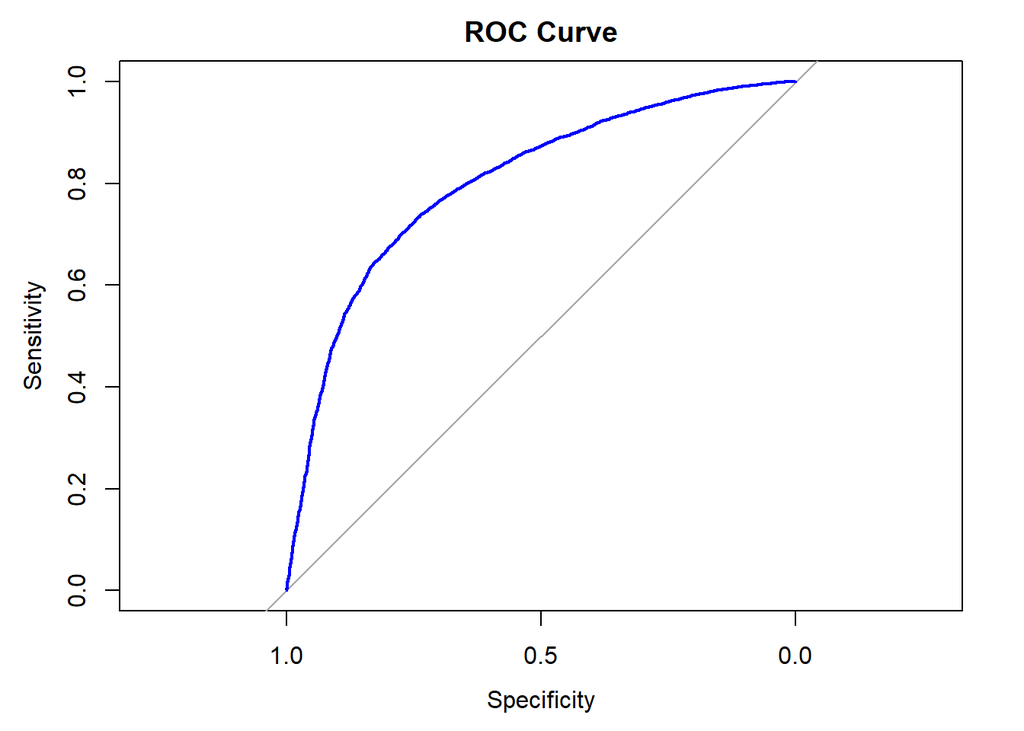

```r
roc_curve_splines <- roc(actual_labels, predicted_probs)
plot(roc_curve_splines, main = "ROC Curve", col = "blue", lwd = 2)
```

```r
auc_spline <- auc(roc_curve_splines)
print(auc_spline)
```

```
## Area under the curve: 0.8015
```

```r
png("images/roc_curve_splines.png", width = 800, height = 600)
plot(roc_curve_splines, main = "ROC Curve", col = "blue", lwd = 2)
dev.off()
```

```r
TN <- cm$table[1, 1]
FP <- cm$table[1, 2]
FN <- cm$table[2, 1]
TP <- cm$table[2, 2]

accuracy <- (TP + TN) / (TP + TN + FP + FN)
precision <- TP / (TP + FP)
recall <- TP / (TP + FN)
specificity <- TN / (TN + FP)
f1_score <- 2 * ((precision * recall) / (precision + recall))
fpr <- FP / (FP + TN)
fnr <- FN / (FN + TP)
fnr_fpr_ratio <- fnr / fpr

splines_metrics_df <- data.frame(
  Metric = c("Accuracy", "Precision", "Recall (Sensitivity)", "Specificity", "F1-Score", "FPR", "FNR", "FNR/FPR Ratio"),
  Value = c(accuracy, precision, recall, specificity, f1_score, fpr, fnr, fnr_fpr_ratio)
)

print(splines_metrics_df)
```

```
##                 Metric     Value
## 1             Accuracy 0.7371907
## 2            Precision 0.7153564
## 3 Recall (Sensitivity) 0.7441149
## 4          Specificity 0.7308975
## 5             F1-Score 0.7294523
## 6                  FPR 0.2691025
## 7                  FNR 0.2558851
## 8        FNR/FPR Ratio 0.9508831
```

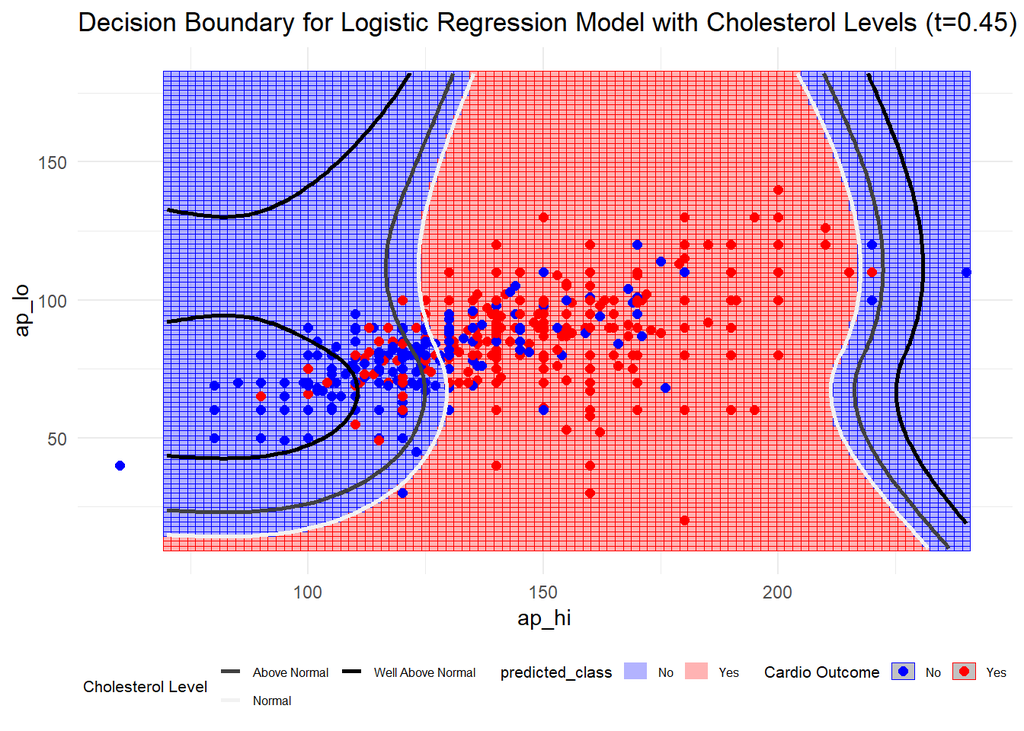

```r
get_mode <- function(x) {
  uniq_x <- unique(x)
  uniq_x[which.max(tabulate(match(x, uniq_x)))]
}
ap_hi_range <- seq(min(train_data$ap_hi), max(train_data$ap_hi), length.out = 100)
ap_lo_range <- seq(min(train_data$ap_lo), max(train_data$ap_lo), length.out = 100)
grid <- expand.grid(ap_hi = ap_hi_range, ap_lo = ap_lo_range)
grid$age <- median(train_data$age, na.rm = TRUE)
grid$height <- median(train_data$height, na.rm = TRUE)
grid$weight <- median(train_data$weight, na.rm = TRUE)
grid$cholesterol <- get_mode(train_data$cholesterol)
grid$gluc <- get_mode(train_data$gluc)
grid$smoke <- get_mode(train_data$smoke)
grid$alco <- get_mode(train_data$alco)
grid$active <- get_mode(train_data$active)
grid$gender <- get_mode(train_data$gender)
ap_hi_spline <- ns(grid$ap_hi, df = 4)
ap_lo_spline <- ns(grid$ap_lo, df = 4)
grid_splines <- cbind(ap_hi_spline, ap_lo_spline)
grid_full <- cbind(grid, grid_splines)
colnames(grid_full) <- c("ap_hi", "ap_lo", "age", "height", "weight", "cholesterol", "gluc", "smoke", "alco", "active", "gender", paste0("ns_ap_hi", 1:4), paste0("ns_ap_lo", 1:4))
grid_full$gender <- factor(grid_full$gender, levels = levels(train_data$gender))
grid_full$cholesterol <- factor(grid_full$cholesterol, levels = levels(train_data$cholesterol))
grid_full$gluc <- factor(grid_full$gluc, levels = levels(train_data$gluc))
grid_full$smoke <- factor(grid_full$smoke, levels = levels(train_data$smoke))
grid_full$alco <- factor(grid_full$alco, levels = levels(train_data$alco))
grid_full$active <- factor(grid_full$active, levels = levels(train_data$active))

grid_full$predicted_probs <- predict(fit_step, newdata = grid_full, type = "response")
grid_full$predicted_class <- ifelse(grid_full$predicted_probs >= 0.45, "Yes", "No")

# Add new data for "well above normal" cholesterol
grid_well_above <- grid_full
grid_well_above$cholesterol <- "well above normal"
grid_well_above$predicted_probs <- predict(fit_step, newdata = grid_well_above, type = "response")
grid_well_above$predicted_class <- ifelse(grid_well_above$predicted_probs >= 0.45, "Yes", "No")

# Add new data for "above normal" cholesterol
grid_above_normal <- grid_full
grid_above_normal$cholesterol <- "above normal"
grid_above_normal$predicted_probs <- predict(fit_step, newdata = grid_above_normal, type = "response")
grid_above_normal$predicted_class <- ifelse(grid_above_normal$predicted_probs >= 0.45, "Yes", "No")

# Add new data for "normal" cholesterol (this is the default scenario)
grid_normal <- grid_full
grid_normal$cholesterol <- "normal"
grid_normal$predicted_probs <- predict(fit_step, newdata = grid_normal, type = "response")
grid_normal$predicted_class <- ifelse(grid_normal$predicted_probs >= 0.45, "Yes", "No")

ggplot(grid_full, aes(x = ap_hi, y = ap_lo, color = predicted_class)) +
  geom_tile(aes(fill = predicted_class), alpha = 0.3) +
  geom_point(data = test_data, aes(x = ap_hi, y = ap_lo, color = factor(cardio)), size = 2) +
  scale_color_manual(values = c("blue", "red")) +
  scale_fill_manual(values = c("blue", "red")) +
  geom_contour(data = grid_well_above, aes(z = predicted_probs, linetype = "Well Above Normal"),
               color = "black", linewidth = 1, breaks = 0.45) +
  geom_contour(data = grid_above_normal, aes(z = predicted_probs, linetype = "Above Normal"),
               color = "gray25", linewidth = 1, breaks = 0.45) +
  geom_contour(data = grid_normal, aes(z = predicted_probs, linetype = "Normal"),
               color = "gray95", linewidth = 1, breaks = 0.45) +
  labs(title = "Decision Boundary for Logistic Regression Model with Cholesterol Levels (t=0.45)",
       x = "ap_hi", y = "ap_lo", color = "Cardio Outcome", linetype = "Cholesterol Level") +
  scale_linetype_manual(values = c("Normal" = "solid", "Above Normal" = "solid", "Well Above Normal" = "solid")) +
  theme_minimal() +
  theme(legend.position = "bottom",
        legend.box = "horizontal",
        legend.title = element_text(size = 8),  # Even smaller legend title size
        legend.text = element_text(size = 6),   # Even smaller legend text size
        legend.key.size = unit(0.6, "lines"),   # Reduce size of legend keys
        legend.key.width = unit(0.8, "lines"),  # Reduce the width of the legend keys
        legend.spacing.x = unit(0.5, "mm"),     # Reduce space between legend items
        legend.spacing.y = unit(0.5, "mm")) +   # Reduce vertical space between items
  guides(linetype = guide_legend(ncol = 2))  # Split the legend into two columns
```

## Results

Let’s compare the results:

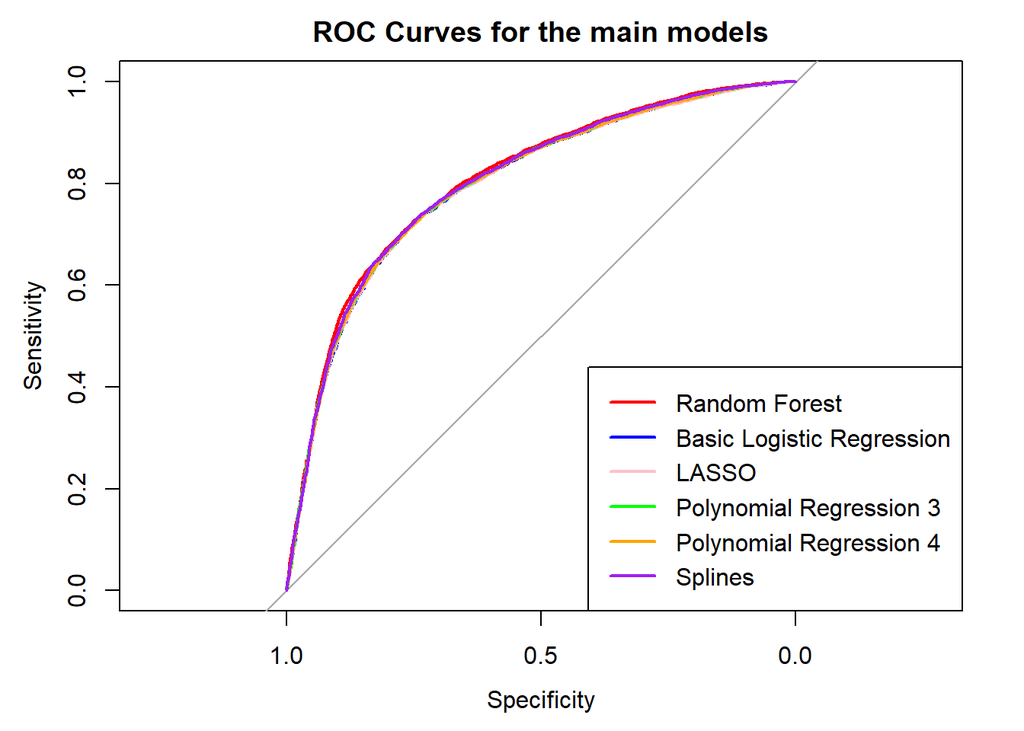

```r
# Plot the ROC curves
plot(roc_curve_rf, col = "red", lwd = 2, main = "ROC Curves for the main models")
plot(roc_curve_lr, col = "blue", lwd = 2, add = TRUE)
plot(roc_curve_lasso, col = "pink", lwd = 2, add = TRUE)
plot(roc_curve_poly3, col = "green", lwd = 2, add = TRUE)
plot(roc_curve_poly4, col = "orange", lwd = 2, add = TRUE)
plot(roc_curve_splines, col = "purple", lwd = 2, add = TRUE)

# Add a legend
legend("bottomright", legend = c("Random Forest", "Basic Logistic Regression", "LASSO", "Polynomial Regression 3",  "Polynomial Regression 4", "Splines"), col = c("red", "blue", "pink", "green", "orange", "purple"), lwd = 2)
```

```r
# Save image
png("images/roc_results.png", width = 800, height = 600)
plot(roc_curve_rf, col = "red", lwd = 2, main = "ROC Curves for the main models")
plot(roc_curve_lr, col = "blue", lwd = 2, add = TRUE)
plot(roc_curve_lasso, col = "pink", lwd = 2, add = TRUE)
plot(roc_curve_poly3, col = "green", lwd = 2, add = TRUE)
plot(roc_curve_poly4, col = "orange", lwd = 2, add = TRUE)
plot(roc_curve_splines, col = "purple", lwd = 2, add = TRUE)
legend("bottomright", legend = c("Random Forest", "Basic Logistic Regression", "LASSO", "Polynomial Regression 3",  "Polynomial Regression 4", "Splines"), col = c("red", "blue", "pink", "green", "orange", "purple"), lwd = 2)
dev.off()
```

```r
# Model results
results <- data.frame(
  Model = c("Random Forest", "Basic Logistic Regression", "LASSO", "Polynomial Regression 3", "Polynomial Regression 4", "Splines"),
  AUC = c(
    rf_auc,
    lr_auc,
    lasso_auc,
    auc_poly3,
    auc_poly4,
    auc_spline
  ),
  Sensitivity = c(
    rf_metrics_df$Value[rf_metrics_df$Metric == "Recall (Sensitivity)"],
    lr_metrics_df$Value[lr_metrics_df$Metric == "Recall (Sensitivity)"],
    lasso_metrics_df$Value[lasso_metrics_df$Metric == "Recall (Sensitivity)"],
    poly3_metrics_df$Value[poly3_metrics_df$Metric == "Recall (Sensitivity)"],
    poly4_metrics_df$Value[poly4_metrics_df$Metric == "Recall (Sensitivity)"],
    splines_metrics_df$Value[splines_metrics_df$Metric == "Recall (Sensitivity)"]
  ),
  Specificity = c(
    rf_metrics_df$Value[rf_metrics_df$Metric == "Specificity"],
    lr_metrics_df$Value[lr_metrics_df$Metric == "Specificity"],
    lasso_metrics_df$Value[lasso_metrics_df$Metric == "Specificity"],
    poly3_metrics_df$Value[poly3_metrics_df$Metric == "Specificity"],
    poly4_metrics_df$Value[poly4_metrics_df$Metric == "Specificity"],
    splines_metrics_df$Value[splines_metrics_df$Metric == "Specificity"]
  )
)
print(results)
```

```
##                       Model       AUC Sensitivity Specificity
## 1             Random Forest 0.8054710   0.7393093   0.7306417
## 2 Basic Logistic Regression 0.7965134   0.7357825   0.7335256
## 3                     LASSO 0.7963870   0.6546657   0.8082192
## 4   Polynomial Regression 3 0.7987797   0.7357825   0.7335256
## 5   Polynomial Regression 4 0.7982589   0.7235856   0.7480894
## 6                   Splines 0.8014987   0.7441149   0.7308975
```

Regarding the interpretation of the models, and based on the vanilla logistic regression, we can draw some interesting conclusions:

1. On average, having cholesterol *well above normal* means that the difference in the log-odds of the probability of having a heart disease is $1.059$ compared to having a *normal* level. So the odds ratio amounts to $e^{1.059} = 2.88$.
2. In the other hand, being physically active means that the difference in the log-odds of the probability of having a heart disease is $-0.229$ compared to having a *normal* level. So the odds ratio amounts to $e^{-0.229} = 0.80$, what results in a $20\%$ of probability less of having heart issues.
3. An increasing of the systolic or diastolic pressure can also negatively affect your health. For each augment in $10$ units to them (while fixing all the other values), we get odds ratios of $1.76$ and $1.10$ respectively.

## References

Hastie, Trevor, Robert Tibshirani, and Jerome Friedman. 2009. “The Elements of Statistical Learning: Data Mining, Inference, and Prediction.” *Springer Series in Statistics*. Springer. https://doi.org/10.1007/978-0-387-84858-7.

Malone, AF, and DN Reddan. 2010. “Pulse Pressure. Why Is It Important?” *Peritoneal Dialysis International*. https://doi.org/10.3747/pdi.2010.00002.

Narloch, Joseph A, and Murray E Brandstater. 1995. “Influence of Breathing Technique on Arterial Blood Pressure During Heavy Weight Lifting.” *Archives of Physical Medicine and Rehabilitation*. Elsevier.

Ulianova, Svetlana. n.d. “Cardiovascular Disease Dataset.” Accessed January 9, 2025. https://www.kaggle.com/datasets/sulianova/cardiovascular-disease-dataset.